# PREDICTIVE ANALYTICS MSBA 6420

## Homework 3

# AADARSH GUPTA

## Total grade: **___** out of *100* points

### Question 1

**(50 points) Use numeric prediction techniques to build a predictive model for the HW3.xlsx dataset. This dataset is provided on the course website and contains data about whether or not different consumers made a purchase in response to a test mailing of a certain catalog and, in case of a purchase, how much money each consumer spent. The data file has a brief description of all the attributes in a separate worksheet. Note that this dataset has two possible outcome variables: Purchase (0/1 value: whether or not the purchase was made) and Spending (numeric value: amount spent).**

**Your tasks:**

**(a) (20 points) Build numeric prediction models that predict Spending based on the other available customer information (obviously, not including the Purchase attribute among the inputs!). Use linear regression, k-NN, regression tree, SVM regreesion and Neural Network and ensembling models. Briefly discuss your explorations and present the best result (best predictive model) for each of these techniques. Compare the techniques; which of them provides the best predictive performance? Please make sure you use best practices for predictive modeling. (I.e., do you need to set which hyper-parameter? Normalize?)**

**(b)** **(20 points) As a variation on this exercise, create a separate “restricted” dataset (i.e., a subset of the** **original dataset), which includes only purchase records (i.e., where Purchase = 1). Build numeric prediction models to predict Spending for this restricted dataset. All the same requirements as for task (a) apply.**

**(c) (10 points) For each predictive modeling technique, discuss the predictive performance differences between the models built for task (a) vs. task (b): which models exhibit better predictive performance? Why do you think that is?**

#### Solution:

For the given problem, we make use of the following numeric prediction models and compare based on the least error. Throughout the modelling process, the workflow was as follows:

1. Find the best split for the data
2. Run a naive implementation of the model
3. Use GridSearch CV to find out the best settings of the hyperparameters
4. For Neural Networks a. We first start with a baseline model on an input and an output layer b. Then we make the model deeper by adding another layer of neurons c. We add one more layer of neurons to see how better is this deeper model compared to the previous one.

Get libraries

```python
import pandas as pd
import numpy as np
import math
from sklearn.neighbors import KNeighborsClassifier as KNC, KNeighborsRegressor as KNR
from sklearn.metrics import confusion_matrix, auc, mean_squared_error
from sklearn.model_selection import StratifiedKFold, cross_val_score, train_test_split, cross_val_predict, GridSearchCV
from matplotlib import pyplot as plt
from sklearn.linear_model import LinearRegression as LR
from pandas.plotting import scatter_matrix
from sklearn.preprocessing import PolynomialFeatures
from sklearn.pipeline import Pipeline
from sklearn.svm import SVR
from sklearn.tree import DecisionTreeRegressor as DTR
```

```python
## Reading data

data = pd.read_excel("HW3_data.xlsx", sheets = 1 )
```

```python
data.head(12)
```

|  | sequence_number | US | source_a | source_c | source_b | source_d | source_e | source_m | source_o | source_h | ... | source_x | source_w | Freq | last_update_days_ago | 1st_update_days_ago | Web order | Gender=male | Address_is_res | Purchase | Spending |
| --- | --- | --- | --- | --- | --- | --- | --- | --- | --- | --- | --- | --- | --- | --- | --- | --- | --- | --- | --- | --- | --- |
| 0 | 1 | 1 | 0 | 0 | 1 | 0 | 0 | 0 | 0 | 0 | ... | 0 | 0 | 2 | 3662 | 3662 | 1 | 0 | 1 | 1 | 127.87 |
| 1 | 2 | 1 | 0 | 0 | 0 | 0 | 1 | 0 | 0 | 0 | ... | 0 | 0 | 0 | 2900 | 2900 | 1 | 1 | 0 | 0 | 0.00 |
| 2 | 3 | 1 | 0 | 0 | 0 | 0 | 0 | 0 | 0 | 0 | ... | 0 | 0 | 2 | 3883 | 3914 | 0 | 0 | 0 | 1 | 127.48 |
| 3 | 4 | 1 | 0 | 1 | 0 | 0 | 0 | 0 | 0 | 0 | ... | 0 | 0 | 1 | 829 | 829 | 0 | 1 | 0 | 0 | 0.00 |
| 4 | 5 | 1 | 0 | 1 | 0 | 0 | 0 | 0 | 0 | 0 | ... | 0 | 0 | 1 | 869 | 869 | 0 | 0 | 0 | 0 | 0.00 |
| 5 | 6 | 1 | 0 | 0 | 0 | 0 | 0 | 0 | 0 | 0 | ... | 0 | 0 | 1 | 1995 | 2002 | 0 | 0 | 1 | 0 | 0.06 |
| 6 | 7 | 1 | 0 | 0 | 0 | 0 | 0 | 0 | 0 | 0 | ... | 0 | 1 | 2 | 1498 | 1529 | 0 | 0 | 1 | 0 | 0.06 |
| 7 | 8 | 1 | 0 | 0 | 1 | 0 | 0 | 0 | 0 | 0 | ... | 0 | 0 | 1 | 3397 | 3397 | 0 | 1 | 0 | 0 | 0.08 |
| 8 | 9 | 1 | 1 | 0 | 0 | 0 | 0 | 0 | 0 | 0 | ... | 0 | 0 | 4 | 525 | 2914 | 1 | 1 | 0 | 1 | 488.50 |
| 9 | 10 | 1 | 1 | 0 | 0 | 0 | 0 | 0 | 0 | 0 | ... | 0 | 0 | 1 | 3215 | 3215 | 0 | 0 | 0 | 1 | 173.50 |
| 10 | 11 | 1 | 0 | 0 | 0 | 0 | 0 | 0 | 0 | 0 | ... | 0 | 0 | 0 | 734 | 734 | 0 | 1 | 0 | 0 | 0.00 |
| 11 | 12 | 1 | 0 | 0 | 0 | 0 | 0 | 0 | 0 | 1 | ... | 0 | 0 | 2 | 1275 | 1313 | 0 | 0 | 1 | 0 | 0.06 |

12 rows × 25 columns

```python
np.transpose(data.describe())
```

|  | count | mean | std | min | 25% | 50% | 75% | max |
| --- | --- | --- | --- | --- | --- | --- | --- | --- |
| sequence_number | 2000.0 | 1000.500000 | 577.494589 | 1.0 | 500.75 | 1000.500 | 1500.2500 | 2000.00 |
| US | 2000.0 | 0.824500 | 0.380489 | 0.0 | 1.00 | 1.000 | 1.0000 | 1.00 |
| source_a | 2000.0 | 0.126500 | 0.332495 | 0.0 | 0.00 | 0.000 | 0.0000 | 1.00 |
| source_c | 2000.0 | 0.056000 | 0.229979 | 0.0 | 0.00 | 0.000 | 0.0000 | 1.00 |
| source_b | 2000.0 | 0.060000 | 0.237546 | 0.0 | 0.00 | 0.000 | 0.0000 | 1.00 |
| source_d | 2000.0 | 0.041500 | 0.199493 | 0.0 | 0.00 | 0.000 | 0.0000 | 1.00 |
| source_e | 2000.0 | 0.151000 | 0.358138 | 0.0 | 0.00 | 0.000 | 0.0000 | 1.00 |
| source_m | 2000.0 | 0.016500 | 0.127420 | 0.0 | 0.00 | 0.000 | 0.0000 | 1.00 |
| source_o | 2000.0 | 0.033500 | 0.179983 | 0.0 | 0.00 | 0.000 | 0.0000 | 1.00 |
| source_h | 2000.0 | 0.052500 | 0.223089 | 0.0 | 0.00 | 0.000 | 0.0000 | 1.00 |
| source_r | 2000.0 | 0.068500 | 0.252665 | 0.0 | 0.00 | 0.000 | 0.0000 | 1.00 |
| source_s | 2000.0 | 0.047000 | 0.211692 | 0.0 | 0.00 | 0.000 | 0.0000 | 1.00 |
| source_t | 2000.0 | 0.021500 | 0.145080 | 0.0 | 0.00 | 0.000 | 0.0000 | 1.00 |
| source_u | 2000.0 | 0.119000 | 0.323869 | 0.0 | 0.00 | 0.000 | 0.0000 | 1.00 |
| source_p | 2000.0 | 0.006000 | 0.077246 | 0.0 | 0.00 | 0.000 | 0.0000 | 1.00 |
| source_x | 2000.0 | 0.018000 | 0.132984 | 0.0 | 0.00 | 0.000 | 0.0000 | 1.00 |
| source_w | 2000.0 | 0.137500 | 0.344461 | 0.0 | 0.00 | 0.000 | 0.0000 | 1.00 |
| Freq | 2000.0 | 1.417000 | 1.405738 | 0.0 | 1.00 | 1.000 | 2.0000 | 15.00 |
| last_update_days_ago | 2000.0 | 2155.101000 | 1141.302846 | 1.0 | 1133.00 | 2280.000 | 3139.2500 | 4188.00 |
| 1st_update_days_ago | 2000.0 | 2435.601500 | 1077.872233 | 1.0 | 1671.25 | 2721.000 | 3353.0000 | 4188.00 |
| Web order | 2000.0 | 0.426000 | 0.494617 | 0.0 | 0.00 | 0.000 | 1.0000 | 1.00 |
| Gender=male | 2000.0 | 0.524500 | 0.499524 | 0.0 | 0.00 | 1.000 | 1.0000 | 1.00 |
| Address_is_res | 2000.0 | 0.221000 | 0.415024 | 0.0 | 0.00 | 0.000 | 0.0000 | 1.00 |
| Purchase | 2000.0 | 0.500000 | 0.500125 | 0.0 | 0.00 | 0.500 | 1.0000 | 1.00 |
| Spending | 2000.0 | 102.560745 | 186.749816 | 0.0 | 0.00 | 1.855 | 152.5325 | 1500.06 |

```python
# Plotting scatter matrix to visualize the data
```

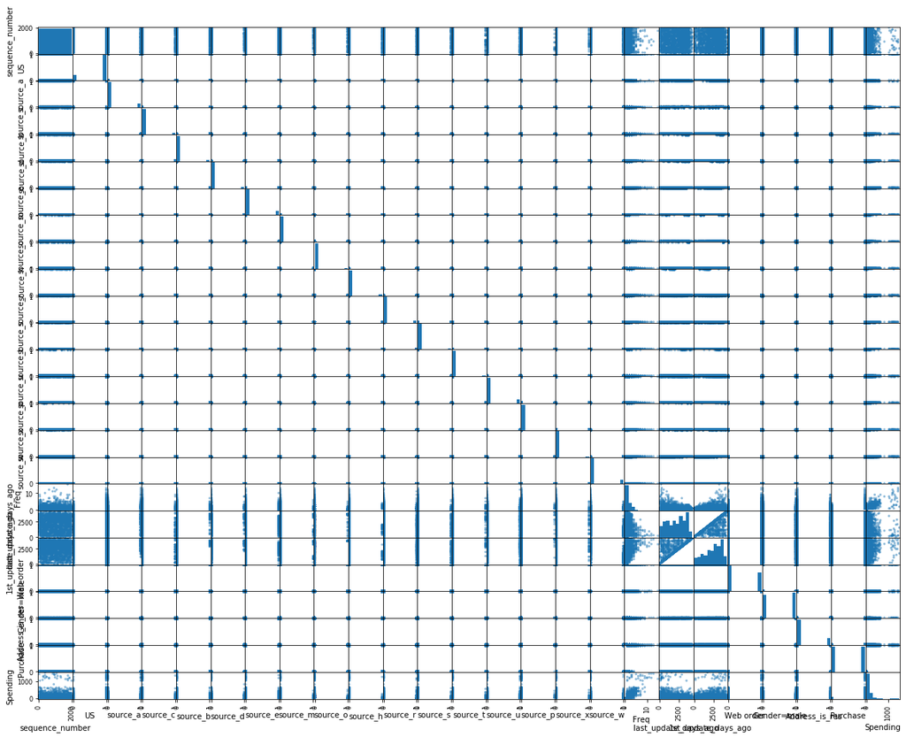

```python
scatter_matrix(data, figsize = (20,16))
plt.show()
```

#### Preparing data for prediction:

Train test split

```python
xtrain, xtest, ytrain, ytest = train_test_split(data.iloc[:,:-2], data['Spending'], test_size = 0.3)
```

### Getting numeric prediction models

1. Linear Regression
2. KNN Regression
3. Support Vector Regression
4. Regression Trees
5. Neural Networks
6. Ensemble Methods

#### 1. Linear regression

```python
# Regressor
reg = LR().fit(xtrain, ytrain)

#Predict
pred = reg.predict(xtest)

#Absolute error (residuals)
abs_err = pred - ytest
abs_perr = pred/ytest -1
```

```python
# Getting R-squared value

reg.score(xtest, ytest)
```

```
0.42354488529772394
```

#### Comparing Actual vs Prediction of test data

```
[]
```

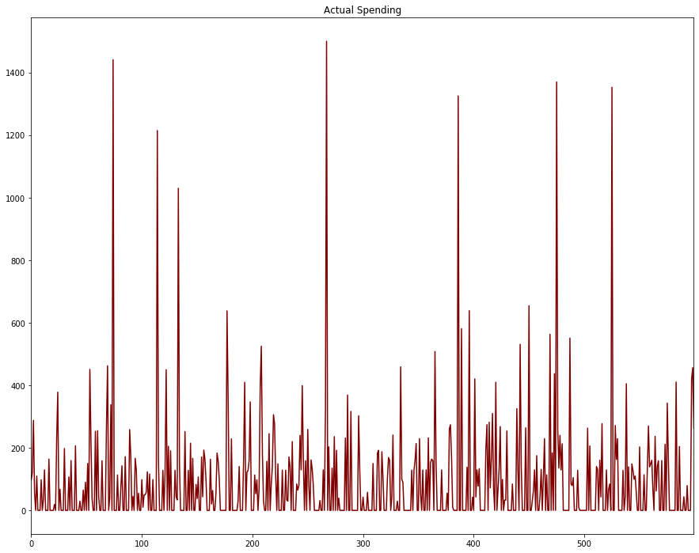

```python
# test data plot
pd.Series(np.array(ytest)).plot(figsize = (15, 12), color = 'maroon')
plt.title('Actual Spending')
plt.plot()
```

```
[]
```

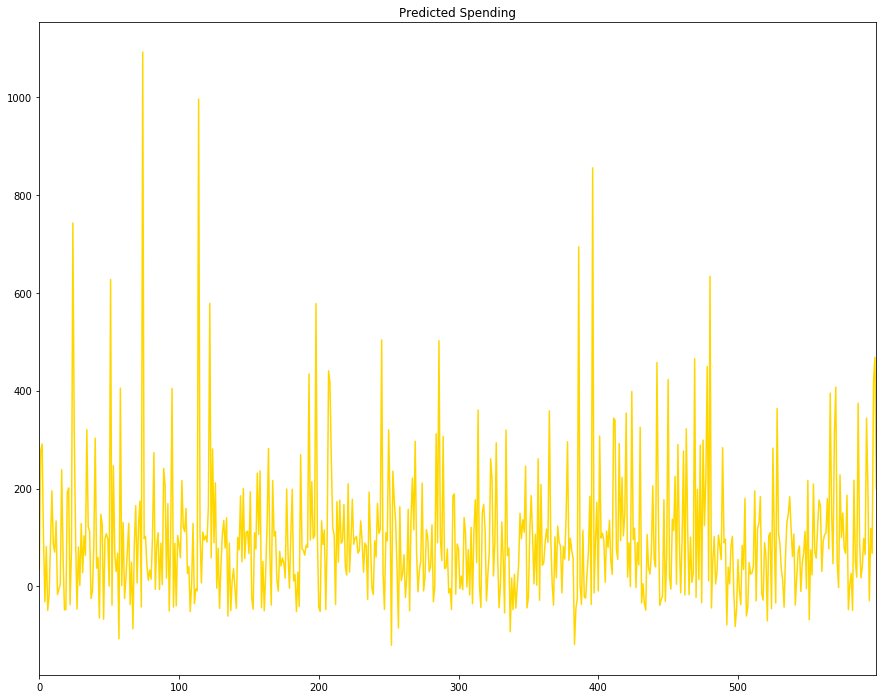

```python
# predicted data plot
pd.Series(pred).plot(figsize = (15, 12), color = 'gold')
plt.title('Predicted Spending')
plt.plot()
```

```
[]
```

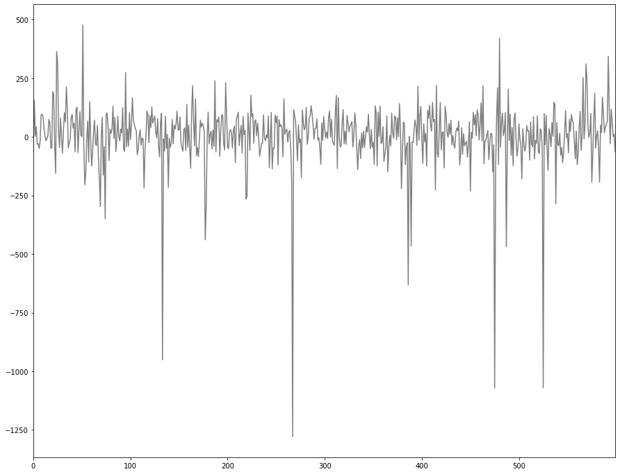

```python
# Residual plot
pd.Series(np.array(abs_err)).plot(figsize = (15, 12), color = 'grey')
plt.plot()
```

```python
# Mean Absolute Error
print ("MAE : ", round(np.mean(abs(abs_err)),2))

# Mean Absolute Percentage Error
print ("MAPE : ", round(np.mean(abs(abs_perr)),2))
```

```
MAE :  79.77
MAPE :  inf
```

```python
# Have to calculate Symmetric MAPE as multiple 0 values make the calculation Inf


def smape(A, F):
    return 100/len(A) * np.sum(2 * np.abs(F - A) / (np.abs(A) + np.abs(F)))


print("SMAPE : ",round(smape(pred, ytest),2))
```

```
SMAPE :  134.46
```

```python
# Mean Squared error

print ("RMSE : ", round(math.sqrt(mean_squared_error(pred, ytest)),2))
```

```
RMSE :  136.57
```

```python
# Iterate over multiple train - test splits to find the best possible for a random state

mae_score = []
mape_score = []
smape_score = []
rmse_score = []
r_score = []

test_size = list(range(10,35,2))
for size in test_size:
    xtrain, xtest, ytrain, ytest = train_test_split(data.iloc[:,:-2], data['Spending'],
                                                    random_state = 1234567890, test_size = size/100)

    # Regressor
    reg = LR().fit(xtrain, ytrain)

    #Predict
    pred = reg.predict(xtest)

    #Absolute error (residuals)
    abs_err = pred - ytest
    abs_perr = pred/ytest -1

    print ("")
    print ("Test size : ", size/100)
    print ("---")

    # R-squared value
    print("R squared : ", round(reg.score(xtest, ytest),2))
    r_score.append(float(round(reg.score(xtest, ytest),2)))

    # Mean Absolute Error
    print ("MAE : ", round(np.mean(abs(abs_err)),2))
    mae_score.append(float(round(np.mean(abs(abs_err)),2)))

    # Mean Absolute Percentage Error
    print ("MAPE : ", round(np.mean(abs(abs_perr)),2))
    mape_score.append(float(round(np.mean(abs(abs_perr)),2)))

    #SMAPE
    print ("SMAPE : ",round(smape(pred, ytest),2))
    smape_score.append(float(round(smape(pred, ytest),2)))

    #RMSE
    print ("RMSE : ", round(math.sqrt(mean_squared_error(pred, ytest)),2))
    rmse_score.append(float(round(math.sqrt(mean_squared_error(pred, ytest)),2)))
```

```
Test size :  0.1
---
R squared :  0.47
MAE :  81.19
MAPE :  inf
SMAPE :  128.78
RMSE :  143.13

Test size :  0.12
---
R squared :  0.47
MAE :  76.98
MAPE :  inf
SMAPE :  128.71
RMSE :  134.63

Test size :  0.14
---
R squared :  0.48
MAE :  75.0
MAPE :  inf
SMAPE :  128.29
RMSE :  128.03

Test size :  0.16
---
R squared :  0.5
MAE :  72.69
MAPE :  inf
SMAPE :  128.6
RMSE :  122.92

Test size :  0.18
---
R squared :  0.6
MAE :  72.74
MAPE :  inf
SMAPE :  127.78
RMSE :  120.1

```

[output cut: 48 more lines]

```
Test size :  0.32
---
R squared :  0.52
MAE :  77.52
MAPE :  inf
SMAPE :  129.88
RMSE :  127.34

Test size :  0.34
---
R squared :  0.54
MAE :  77.54
MAPE :  inf
SMAPE :  129.35
RMSE :  127.29
```

```python
scores = pd.DataFrame(mae_score, columns = ['mae_score'], index = [test_size])
scores['smape_score']=smape_score
scores['rmse_score'] = rmse_score
scores['r-squared'] = np.multiply(r_score,100)
```

```
[]
```

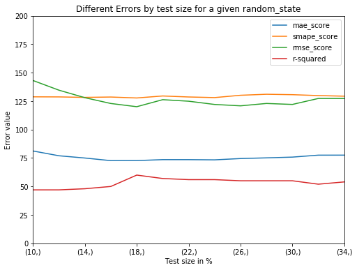

```python
scores.plot(figsize = (8,6))
plt.title("Different Errors by test size for a given random_state")
plt.xlabel("Test size in %")
plt.ylabel("Error value")
plt.ylim([0,200])
plt.plot()
```

```python
# Using CV to predict spending
```

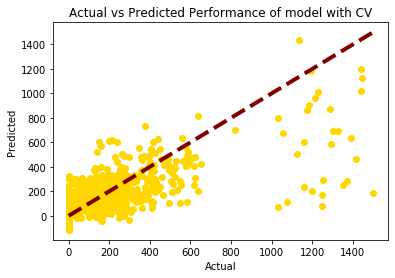

```python
target = data['Spending']
predicted = cross_val_predict(LR(), data.iloc[:,:-2], target, cv=10)
fig, ax = plt.subplots()
ax.scatter(target, predicted, color = 'gold')
ax.plot([target.min(), target.max()], [target.min(), target.max()], 'k--', color = 'maroon',lw=4)
ax.set_xlabel('Actual')
ax.set_ylabel('Predicted')
ax.set_title("Actual vs Predicted Performance of model with CV")
plt.show()
```

From the above plot, we see that the model has problems with the larger values of Spending as it fails to predict them properly.  
Further, the model is predicting negative spending in some cases for very less spending as test. This shows the shortcomings of the model.

#### 2. KNN Regression

```python
xtrain, xtest, ytrain, ytest = train_test_split(data.iloc[:,:-2], data['Spending'], test_size = 0.3)
```

```python
reg = KNR()
reg.fit(xtrain, ytrain)
pred = reg.predict(xtest)
```

```python
# Iterate over multiple train - test splits to find the best possible for a random state

mae_score = []
mape_score = []
smape_score = []
rmse_score = []
r_score = []

test_size = list(range(10,35,2))
for size in test_size:
    xtrain, xtest, ytrain, ytest = train_test_split(data.iloc[:,:-2], data['Spending'],
                                                    random_state = 1234567890, test_size = size/100)

    # Regressor
    reg = KNR(n_neighbors = 10).fit(xtrain, ytrain)

    #Predict
    pred = reg.predict(xtest)

    #Absolute error (residuals)
    abs_err = pred - ytest
    abs_perr = pred/ytest -1

    print ("")
    print ("Test size : ", size/100)
    print ("---")

    # R-squared value
    print("R squared : ", round(reg.score(xtest, ytest),2))
    r_score.append(float(round(reg.score(xtest, ytest),2)))

    # Mean Absolute Error
    print ("MAE : ", round(np.mean(abs(abs_err)),2))
    mae_score.append(float(round(np.mean(abs(abs_err)),2)))

    # Mean Absolute Percentage Error
    print ("MAPE : ", round(np.mean(abs(abs_perr)),2))
    mape_score.append(float(round(np.mean(abs(abs_perr)),2)))

    #SMAPE
    print ("SMAPE : ",round(smape(pred, ytest),2))
    smape_score.append(float(round(smape(pred, ytest),2)))

    #RMSE
    print ("RMSE : ", round(math.sqrt(mean_squared_error(pred, ytest)),2))
    rmse_score.append(float(round(math.sqrt(mean_squared_error(pred, ytest)),2)))
```

```
Test size :  0.1
---
R squared :  0.13
MAE :  101.15
MAPE :  inf
SMAPE :  133.78
RMSE :  183.06

Test size :  0.12
---
R squared :  0.13
MAE :  95.84
MAPE :  inf
SMAPE :  133.98
RMSE :  171.57

Test size :  0.14
---
R squared :  0.14
MAE :  93.8
MAPE :  inf
SMAPE :  134.69
RMSE :  164.05

Test size :  0.16
---
R squared :  0.18
MAE :  91.87
MAPE :  inf
SMAPE :  135.93
RMSE :  158.02

Test size :  0.18
---
R squared :  0.28
MAE :  96.12
MAPE :  inf
SMAPE :  136.47
RMSE :  160.98

```

[output cut: 48 more lines]

```
Test size :  0.32
---
R squared :  0.23
MAE :  95.69
MAPE :  inf
SMAPE :  138.39
RMSE :  161.61

Test size :  0.34
---
R squared :  0.25
MAE :  95.94
MAPE :  inf
SMAPE :  138.04
RMSE :  162.2
```

```python
scores = pd.DataFrame(mae_score, columns = ['mae_score'], index = [test_size])
scores['smape_score']=smape_score
scores['rmse_score'] = rmse_score
scores['r-squared'] = np.multiply(r_score,100)
```

```
[]
```

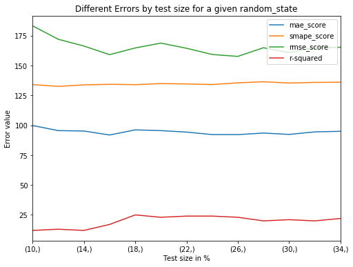

```python
scores.plot(figsize = (8,6))
plt.title("Different Errors by test size for a given random_state")
plt.xlabel("Test size in %")
plt.ylabel("Error value")
plt.plot()
```

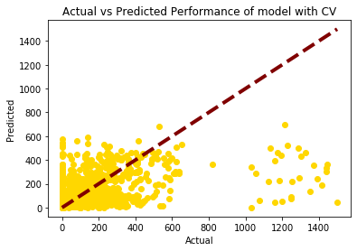

```python
target = data['Spending']
predicted = cross_val_predict(KNR(n_neighbors = 12), data.iloc[:,:-2], target, cv=10)
fig, ax = plt.subplots()
ax.scatter(target, predicted, color = 'gold')
ax.plot([target.min(), target.max()], [target.min(), target.max()], 'k--', color = 'maroon',lw=4)
ax.set_xlabel('Actual')
ax.set_ylabel('Predicted')
ax.set_title("Actual vs Predicted Performance of model with CV")
plt.show()
```

Running the model with GridSearch on parameters to improve the performance:

#### *GridSearch Cross Validation:*

```python
# Determining the best KNN Model

xtrain, xtest, ytrain, ytest = train_test_split(data.iloc[:,:-2], data['Spending'], test_size = 0.18)

search_grid = dict (n_neighbors=list(range(1,20)), weights = ["distance", "uniform"], algorithm = ["ball_tree", "kd_tree", "auto"])
knnr = KNR()
grid_model = GridSearchCV(knnr, search_grid, cv = 10, scoring = "r2")
grid_model.fit(xtrain,ytrain)

print( "KNN ")
print( "====")

print ("Best Score", grid_model.best_score_)
print ("Best Params", grid_model.best_params_)
print ("Best estimator has the following parameters", grid_model.best_estimator_)
#print (classification_report(ytest,grid_model.predict(xtest)))
```

```
KNN
====
Best Score 0.23124510118468697
Best Params {'algorithm': 'ball_tree', 'n_neighbors': 18, 'weights': 'uniform'}
Best estimator has the following parameters KNeighborsRegressor(algorithm='ball_tree', leaf_size=30, metric='minkowski',
                    metric_params=None, n_jobs=None, n_neighbors=18, p=2,
                    weights='uniform')
```

However, even with the grid search's best model, we only achieve an R score value of ~0.23. Thus this is not the best model yet.

#### 3. Support Vector Regression

```python
xtrain, xtest, ytrain, ytest = train_test_split(data.iloc[:,:-2], data['Spending'], test_size = 0.3)
```

```python
reg = SVR(kernel = 'rbf', gamma = 'scale')
reg.fit(xtrain, ytrain)
pred = reg.predict(xtest)
```

```python
# Iterate over multiple train - test splits to find the best possible for a random state

mae_score = []
mape_score = []
smape_score = []
rmse_score = []
r_score = []

test_size = list(range(10,35,2))
for size in test_size:
    xtrain, xtest, ytrain, ytest = train_test_split(data.iloc[:,:-2], data['Spending'],
                                                    random_state = 1234567890, test_size = size/100)

    # Regressor
    reg = SVR(kernel = 'rbf', gamma = 'auto', C = 10).fit(xtrain, ytrain)

    #Predict
    pred = reg.predict(xtest)

    #Absolute error (residuals)
    abs_err = pred - ytest
    abs_perr = pred/ytest -1

    print ("")
    print ("Test size : ", size/100)
    print ("---")

    # R-squared value
    print("R squared : ", round(reg.score(xtest, ytest),2))
    r_score.append(float(round(reg.score(xtest, ytest),2)))

    # Mean Absolute Error
    print ("MAE : ", round(np.mean(abs(abs_err)),2))
    mae_score.append(float(round(np.mean(abs(abs_err)),2)))

    # Mean Absolute Percentage Error
    print ("MAPE : ", round(np.mean(abs(abs_perr)),2))
    mape_score.append(float(round(np.mean(abs(abs_perr)),2)))

    #SMAPE
    print ("SMAPE : ",round(smape(pred, ytest),2))
    smape_score.append(float(round(smape(pred, ytest),2)))

    #RMSE
    print ("RMSE : ", round(math.sqrt(mean_squared_error(pred, ytest)),2))
    rmse_score.append(float(round(math.sqrt(mean_squared_error(pred, ytest)),2)))
```

```
Test size :  0.1
---
R squared :  -0.26
MAE :  108.65
MAPE :  inf
SMAPE :  182.26
RMSE :  219.37

Test size :  0.12
---
R squared :  -0.26
MAE :  103.82
MAPE :  inf
SMAPE :  182.72
RMSE :  206.99

Test size :  0.14
---
R squared :  -0.27
MAE :  102.46
MAPE :  inf
SMAPE :  183.09
RMSE :  199.92

Test size :  0.16
---
R squared :  -0.27
MAE :  100.42
MAPE :  inf
SMAPE :  183.02
RMSE :  196.68

Test size :  0.18
---
R squared :  -0.27
MAE :  107.81
MAPE :  inf
SMAPE :  183.1
RMSE :  213.71

```

[output cut: 48 more lines]

```
Test size :  0.32
---
R squared :  -0.26
MAE :  103.8
MAPE :  inf
SMAPE :  182.57
RMSE :  206.77

Test size :  0.34
---
R squared :  -0.27
MAE :  105.83
MAPE :  inf
SMAPE :  182.69
RMSE :  210.15
```

```python
scores = pd.DataFrame(mae_score, columns = ['mae_score'], index = [test_size])
scores['smape_score']=smape_score
scores['rmse_score'] = rmse_score
scores['r-squared'] = np.multiply(r_score,100)
```

```
[]
```

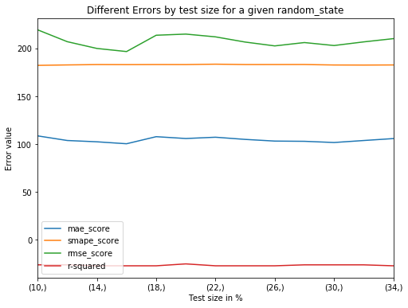

```python
scores.plot(figsize = (8,6))
plt.title("Different Errors by test size for a given random_state")
plt.xlabel("Test size in %")
plt.ylabel("Error value")
plt.plot()
```

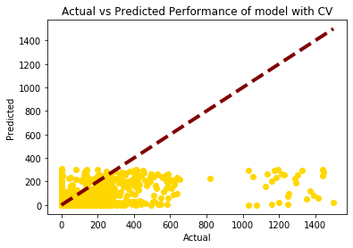

```python
target = data['Spending']
predicted = cross_val_predict(SVR(gamma = 'scale' ,C = 10), data.iloc[:,:-2], target, cv=10)
fig, ax = plt.subplots()
ax.scatter(target, predicted, color = 'gold')
ax.plot([target.min(), target.max()], [target.min(), target.max()], 'k--', color = 'maroon',lw=4)
ax.set_xlabel('Actual')
ax.set_ylabel('Predicted')
ax.set_title("Actual vs Predicted Performance of model with CV")
plt.show()
```

Using a GridSearch Cross Validation to check if we can achieve a better model:

#### *GridSearch CV:*

```python
xtrain, xtest, ytrain, ytest = train_test_split(data.iloc[:,:-2], data['Spending'], test_size = 0.3)

params = dict (C=list(range(1,20,4)), kernel = ['rbf'], gamma = list(range(1,20,4)))
cvm_reg = SVR()

svm_clf = GridSearchCV(cvm_reg, params, cv= 10, scoring = 'r2')
svm_clf.fit(xtrain, ytrain)

print( "SVR")
print( "===")

print ("Best Score", svm_clf.best_score_)
print ("Best Params", svm_clf.best_params_)
print ("Best estimator has the following parameters", svm_clf.best_estimator_)
```

```
SVR
===
Best Score -0.23505020657729545
Best Params {'C': 17, 'gamma': 1, 'kernel': 'rbf'}
Best estimator has the following parameters SVR(C=17, cache_size=200, coef0=0.0, degree=3, epsilon=0.1, gamma=1,
    kernel='rbf', max_iter=-1, shrinking=True, tol=0.001, verbose=False)
```

Even with the Grid Search, we can only achieve a negative R-squared value. Therefore, the model is not usable in this case.

#### 4. Regression Trees

```python
xtrain, xtest, ytrain, ytest = train_test_split(data.iloc[:,:-2], data['Spending'], test_size = 0.3)
```

```python
reg = DTR()
```

```python
reg.fit(xtrain, ytrain)
```

```
DecisionTreeRegressor(criterion='mse', max_depth=None, max_features=None,
                      max_leaf_nodes=None, min_impurity_decrease=0.0,
                      min_impurity_split=None, min_samples_leaf=1,
                      min_samples_split=2, min_weight_fraction_leaf=0.0,
                      presort=False, random_state=None, splitter='best')
```

```python
pred = reg.predict(xtest)
```

```python
# Getting R-squared value

reg.score(xtest, ytest)
```

```
0.15020325076974284
```

```python
# Iterate over multiple train - test splits to find the best possible for a random state

mae_score = []
mape_score = []
smape_score = []
rmse_score = []
r_score = []

test_size = list(range(10,35,2))
for size in test_size:
    xtrain, xtest, ytrain, ytest = train_test_split(data.iloc[:,:-2], data['Spending'],
                                                    random_state = 1234567890, test_size = size/100)

    # Regressor
    reg = DTR().fit(xtrain, ytrain)

    #Predict
    pred = reg.predict(xtest)

    #Absolute error (residuals)
    abs_err = pred - ytest
    abs_perr = pred/ytest -1

    print ("")
    print ("Test size : ", size/100)
    print ("---")

    # R-squared value
    print("R squared : ", round(reg.score(xtest, ytest),2))
    r_score.append(float(round(reg.score(xtest, ytest),2)))

    # Mean Absolute Error
    print ("MAE : ", round(np.mean(abs(abs_err)),2))
    mae_score.append(float(round(np.mean(abs(abs_err)),2)))

    # Mean Absolute Percentage Error
    print ("MAPE : ", round(np.mean(abs(abs_perr)),2))
    mape_score.append(float(round(np.mean(abs(abs_perr)),2)))

    #SMAPE
    print ("SMAPE : ",round(smape(pred, ytest),2))
    smape_score.append(float(round(smape(pred, ytest),2)))

    #RMSE
    print ("RMSE : ", round(math.sqrt(mean_squared_error(pred, ytest)),2))
    rmse_score.append(float(round(math.sqrt(mean_squared_error(pred, ytest)),2)))
```

```
Test size :  0.1
---
R squared :  -0.23
MAE :  99.18
MAPE :  inf
SMAPE :  79.87
RMSE :  216.6

Test size :  0.12
---
R squared :  -0.27
MAE :  95.12
MAPE :  inf
SMAPE :  75.08
RMSE :  207.33

Test size :  0.14
---
R squared :  -0.11
MAE :  86.75
MAPE :  inf
SMAPE :  76.3
RMSE :  186.25

Test size :  0.16
---
R squared :  0.11
MAE :  77.95
MAPE :  inf
SMAPE :  73.43
RMSE :  164.36

Test size :  0.18
---
R squared :  -0.01
MAE :  90.74
MAPE :  inf
SMAPE :  76.53
RMSE :  190.52

```

[output cut: 48 more lines]

```
Test size :  0.32
---
R squared :  0.15
MAE :  84.3
MAPE :  inf
SMAPE :  75.66
RMSE :  169.4

Test size :  0.34
---
R squared :  0.17
MAE :  81.79
MAPE :  inf
SMAPE :  74.13
RMSE :  170.64
```

```python
scores = pd.DataFrame(mae_score, columns = ['mae_score'], index = [test_size])
scores['smape_score']=smape_score
scores['rmse_score'] = rmse_score
scores['r-squared'] = np.multiply(r_score,100)
```

```
[]
```

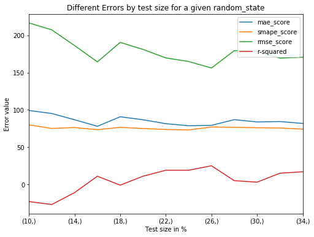

```python
scores.plot(figsize = (8,6))
plt.title("Different Errors by test size for a given random_state")
plt.xlabel("Test size in %")
plt.ylabel("Error value")
plt.plot()
```

We therefore choose a test size of 26% to carry our analysis

Using GridSearch to find the best performance from the model:

#### *Grid Search CV*

```python
xtrain, xtest, ytrain, ytest = train_test_split(data.iloc[:,:-2], data['Spending'], test_size = 0.26)

params = dict(max_depth = list(range(1, 21)))
tree_reg = DTR()

#Compute macro score aggregations: score for each, then aggregate
dt_clf = GridSearchCV(tree_reg, params, cv= 8, scoring = 'r2')
dt_clf.fit(xtrain, ytrain)


print( "DECISION TREE")

print ("Best Score", dt_clf.best_score_)
print ("Best Params", dt_clf.best_params_)
print ("Best estimator has the following parameters", dt_clf.best_estimator_)
```

```
DECISION TREE
Best Score 0.5305834064245211
Best Params {'max_depth': 5}
Best estimator has the following parameters DecisionTreeRegressor(criterion='mse', max_depth=5, max_features=None,
                      max_leaf_nodes=None, min_impurity_decrease=0.0,
                      min_impurity_split=None, min_samples_leaf=1,
                      min_samples_split=2, min_weight_fraction_leaf=0.0,
                      presort=False, random_state=None, splitter='best')
```

#### 5. Neural Networks for regression

```python
from keras.models import Sequential
from keras.layers import Dense
from keras.wrappers.scikit_learn import KerasRegressor
from sklearn.model_selection import KFold
from sklearn.preprocessing import StandardScaler
from sklearn.pipeline import Pipeline
```

```python
# define base model
def baseline_model():
# create model
    model = Sequential()
    model.add(Dense(23, input_dim=23, kernel_initializer='normal', activation='relu'))
    model.add(Dense(1, kernel_initializer='normal'))
    # Compile model
    model.compile(loss='mean_squared_error', optimizer='adam')
    return model
```

```python
#Get data

X = data.iloc[:,:-2]
Y = data['Spending']
```

```python
# evaluate model
estimator = KerasRegressor(build_fn=baseline_model, epochs=100, batch_size=50, verbose=0)
kfold = KFold(n_splits=10)
results = cross_val_score(estimator, X, Y, cv=kfold)
print("Baseline: %.2f (%.2f) MSE" % (results.mean(), results.std()))
```

```
Baseline: -25694.91 (10801.51) MSE
```

```python
print ("This translates to the RMSE value of ", np.sqrt(abs(results.mean())))
```

```
This translates to the RMSE value of  160.29633184032892
```

Modifying the model architecture to add another layer: Making it deeper!!!

```python
# define the model
def larger_model():
    # create model
    model = Sequential()
    model.add(Dense(23, input_dim=23, kernel_initializer='normal', activation='relu'))
    model.add(Dense(10, kernel_initializer='normal', activation='relu'))
    model.add(Dense(1, kernel_initializer='normal'))
    # Compile model
    model.compile(loss='mean_squared_error', optimizer='adam')
    return model
# evaluate model with standardized dataset
estimators = []
estimators.append(('standardize', StandardScaler()))
estimators.append(('mlp', KerasRegressor(build_fn=larger_model, epochs=50, batch_size=50, verbose=0)))
pipeline = Pipeline(estimators)
kfold = KFold(n_splits=10)
results = cross_val_score(pipeline, X, Y, cv=kfold)
print("Larger: %.2f (%.2f) MSE" % (results.mean(), results.std()))
```

```
Larger: -16030.19 (7344.56) MSE
```

```python
print ("RMSE : ", np.sqrt(abs(results.mean())))
```

```
RMSE :  126.61038388157831
```

Using a deeper model, we reduce the MSE significantly from the previous model!!

```python
#Adding another layer to the model to improve the performance further:


# define the model
def larger_model():
    # create model
    model = Sequential()
    model.add(Dense(23, input_dim=23, kernel_initializer='normal', activation='relu'))
    model.add(Dense(12, kernel_initializer='normal', activation='relu'))
    model.add(Dense(6, kernel_initializer='normal', activation='relu'))
    model.add(Dense(1, kernel_initializer='normal'))
    # Compile model
    model.compile(loss='mean_squared_error', optimizer='adam')
    return model
# evaluate model with standardized dataset
estimators = []
estimators.append(('standardize', StandardScaler()))
estimators.append(('mlp', KerasRegressor(build_fn=larger_model, epochs=50, batch_size=25, verbose=0)))
pipeline = Pipeline(estimators)
kfold = KFold(n_splits=10)
results = cross_val_score(pipeline, X, Y, cv=kfold)
print("Larger: %.2f (%.2f) MSE" % (results.mean(), results.std()))
```

```
Larger: -33679.06 (25489.69) MSE
```

```python
print ("RMSE : " ,np.sqrt(abs(results.mean())))
```

[output not shown]

#### 6. Ensemble Models

For our ensemble approach, we use the AdaBoosting regressor on top of the best regression model we achieved previously:

1. Decision Tree Regressor (Regression Tree)

   > *{criterion='mse', max_depth=5, max_features=None, max_leaf_nodes=None, min_impurity_decrease=0.0, min_impurity_split=None, min_samples_leaf=1, min_samples_split=2, min_weight_fraction_leaf=0.0, presort=False, random_state=None, splitter='best'}*

```python
from sklearn.ensemble import AdaBoostRegressor
```

```python
model_score = []
params = []
for max_depth in range(1,20):
    for criterion in ['mae', 'mse']:
        for loss in ['linear','square' ,'exponential']:
            for estimators in [5,10,15]:
                xtrain, xtest, ytrain, ytest = train_test_split(data.iloc[:,:-2], data['Spending'], test_size = 0.26)
                model = AdaBoostRegressor(base_estimator  = DTR(criterion=criterion, max_depth=max_depth, max_features=None,
                                                 max_leaf_nodes=None, min_impurity_decrease=0.0,
                                                 min_impurity_split=None, min_samples_leaf=1,
                                                 min_samples_split=2, min_weight_fraction_leaf=0.0,
                                                 presort=False, random_state=None, splitter='best'),
                              n_estimators = estimators, loss = loss)
                model.fit(xtrain, ytrain)
                model_score.append(model.score(xtest, ytest))
                params.append((max_depth, criterion, loss, estimators))

                #plt.plot(params, model_score)
                #plt.show()
```

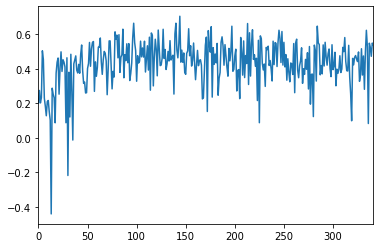

```python
pd.Series(model_score).plot()
plt.plot(max(model_score), 'r--')
plt.show()
```

By following a brute force approach over 342 iterations to regression and finding parameters, we see that the maximium score achoieved from AdaBoosting is more than the one achieved our best model above - by Regression Tree. When we compare this with our many iterations of the regression tree model with Gridsearch (below), we see that the AadBoosting has a better average performance as well.

```python
print ("Max score : ",max(model_score))
print ("Average score : ", np.mean(model_score))
```

```
Max score :  0.7040581174652716
Average score :  0.430132085575376
```

```python
best_score = []
best_params = []

for i in range(50):
    xtrain, xtest, ytrain, ytest = train_test_split(data.iloc[:,:-2], data['Spending'], test_size = 0.26)
    params = dict(max_depth = list(range(1, 21)))
    tree_reg = DTR()

    #Compute macro score aggregations: score for each, then aggregate
    dt_clf = GridSearchCV(tree_reg, params, cv= 8, scoring = 'r2')
    dt_clf.fit(xtrain, ytrain)


    #print ("Best Score", dt_clf.best_score_)
    best_score.append(dt_clf.best_score_)
    best_params.append(dt_clf.best_params_)
#    print ("Best Params", dt_clf.best_params_)
#   print ("Best estimator has the following parameters", dt_clf.best_estimator_)
```

[output not shown]

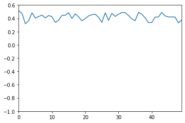

```python
pd.Series(best_score).plot()
plt.plot(max(best_score), 'r--')
plt.ylim([-1,.60])
plt.show()
```

```python
print ("AdaBoost")
print ("--------")
print ("Max Score : ",round(max(model_score),3))
print ("Average score : ", np.mean(model_score).round(3))
print ("")
print ("")

print ("Regression Tree with GridSearchCV")
print ("---------------------------------")
print ("Max Score : ", round(max(best_score),3))
print ("Average Score : ", np.mean(best_score).round(3))
```

```
AdaBoost
--------
Max Score :  0.704
Average score :  0.43


Regression Tree with GridSearchCV
---------------------------------
Max Score :  0.514
Average Score :  0.422
```

Therefore, we select Ensemble Model : AdaBoost as our best regression model!

### Part (b) Variation

```python
restrict_data = data[data['Purchase']==1]
```

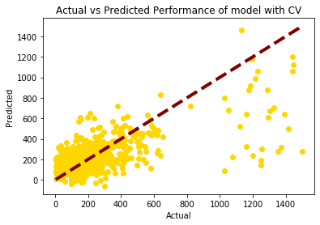

```python
target = restrict_data['Spending']
predicted = cross_val_predict(LR(), restrict_data.iloc[:,:-2], target, cv=10)
fig, ax = plt.subplots()
ax.scatter(target, predicted, color = 'gold')
ax.plot([target.min(), target.max()], [target.min(), target.max()], 'k--', color = 'maroon',lw=4)
ax.set_xlabel('Actual')
ax.set_ylabel('Predicted')
ax.set_title("Actual vs Predicted Performance of model with CV")
plt.show()
```

```python
# Iterate over multiple train - test splits to find the best possible for a random state

mae_score = []
mape_score = []
smape_score = []
rmse_score = []
r_score = []

test_size = list(range(10,35,2))
for size in test_size:
    xtrain, xtest, ytrain, ytest = train_test_split(restrict_data.iloc[:,:-2], restrict_data['Spending'],
                                                    random_state = 1234567890, test_size = size/100)

    # Regressor
    reg = KNR(n_neighbors = 10).fit(xtrain, ytrain)

    #Predict
    pred = reg.predict(xtest)

    #Absolute error (residuals)
    abs_err = pred - ytest
    abs_perr = pred/ytest -1
    r_score.append(float(round(reg.score(xtest, ytest),2)))

    mae_score.append(float(round(np.mean(abs(abs_err)),2)))

    mape_score.append(float(round(np.mean(abs(abs_perr)),2)))

    smape_score.append(float(round(smape(pred, ytest),2)))

    rmse_score.append(float(round(math.sqrt(mean_squared_error(pred, ytest)),2)))
```

```python
scores = pd.DataFrame(mae_score, columns = ['mae_score'], index = [test_size])
scores['smape_score']=smape_score
scores['rmse_score'] = rmse_score
scores['r-squared'] = np.multiply(r_score,100)
```

```
[]
```

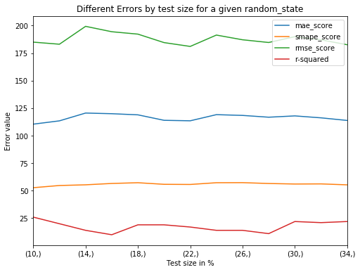

```python
scores.plot(figsize = (8,6))
plt.title("Different Errors by test size for a given random_state")
plt.xlabel("Test size in %")
plt.ylabel("Error value")
plt.plot()
```

#### 2. KNN Regression

```python
# Determining the best KNN Model

xtrain, xtest, ytrain, ytest = train_test_split(restrict_data.iloc[:,:-2], restrict_data['Spending'], test_size = 0.18)

search_grid = dict (n_neighbors=list(range(1,20)), weights = ["distance", "uniform"], algorithm = ["ball_tree", "kd_tree", "auto"])
knnr = KNR()
grid_model = GridSearchCV(knnr, search_grid, cv = 10, scoring = "r2")
grid_model.fit(xtrain,ytrain)

print( "KNN ")
print( "====")

print ("Best Score", grid_model.best_score_)
print ("Best Params", grid_model.best_params_)
print ("Best estimator has the following parameters", grid_model.best_estimator_)
#print (classification_report(ytest,grid_model.predict(xtest)))
```

```
KNN
====
Best Score 0.10724093946693873
Best Params {'algorithm': 'ball_tree', 'n_neighbors': 16, 'weights': 'uniform'}
Best estimator has the following parameters KNeighborsRegressor(algorithm='ball_tree', leaf_size=30, metric='minkowski',
                    metric_params=None, n_jobs=None, n_neighbors=16, p=2,
                    weights='uniform')
```

#### 3. SVM Regression

```python
xtrain, xtest, ytrain, ytest = train_test_split(restrict_data.iloc[:,:-2], restrict_data['Spending'], test_size = 0.26)

params = dict (C=list(range(1,20,4)), kernel = ['rbf'], gamma = list(range(1,20,4)))
cvm_reg = SVR()

svm_clf = GridSearchCV(cvm_reg, params, cv= 10, scoring = 'r2')
svm_clf.fit(xtrain, ytrain)

print( "SVR")
print( "===")

print ("Best Score", svm_clf.best_score_)
print ("Best Params", svm_clf.best_params_)
print ("Best estimator has the following parameters", svm_clf.best_estimator_)
```

```
SVR
===
Best Score -0.05009844118838456
Best Params {'C': 1, 'gamma': 1, 'kernel': 'rbf'}
Best estimator has the following parameters SVR(C=1, cache_size=200, coef0=0.0, degree=3, epsilon=0.1, gamma=1,
    kernel='rbf', max_iter=-1, shrinking=True, tol=0.001, verbose=False)
```

#### 4. Regression Trees

```python
best_score_restrict = []
best_params_restrict = []

for i in range(50):
    xtrain, xtest, ytrain, ytest = train_test_split(restrict_data.iloc[:,:-2], restrict_data['Spending'], test_size = 0.26)
    params = dict(max_depth = list(range(1, 21)))
    tree_reg = DTR()

    #Compute macro score aggregations: score for each, then aggregate
    dt_clf = GridSearchCV(tree_reg, params, cv= 8, scoring = 'r2')
    dt_clf.fit(xtrain, ytrain)


    print ("Best Score", dt_clf.best_score_)
    best_score_restrict.append(dt_clf.best_score_)
    best_params_restrict.append(dt_clf.best_params_)
#    print ("Best Params", dt_clf.best_params_)
#   print ("Best estimator has the following parameters", dt_clf.best_estimator_)

import warnings
warnings.filterwarnings("ignore")
```

```
Best Score 0.2649762277829437
Best Score 0.3048808854246309
Best Score 0.3401748070984715
Best Score 0.38930352695884196
Best Score 0.3092535094621271
Best Score 0.3842818259250111
Best Score 0.2504273691145992
Best Score 0.20164531360205967
Best Score 0.28859652702970723
Best Score 0.35582227694155044
Best Score 0.31397219547392813
Best Score 0.2862054461198157
Best Score 0.2913312384756225
Best Score 0.40228430459058895
Best Score 0.3259714655976277
Best Score 0.36804851702529695
Best Score 0.269467479701217
Best Score 0.31195515542107666
Best Score 0.33250810417329146
Best Score 0.3889192053354385
Best Score 0.3941505794772449
Best Score 0.1942251516457826
Best Score 0.3434523766548915
Best Score 0.2889415941462275
Best Score 0.4226193715388476
Best Score 0.34733239094299934
Best Score 0.31948865088649964
Best Score 0.4511771659402947
Best Score 0.38837108637619083
Best Score 0.37481566045961456
Best Score 0.32014976944573154
Best Score 0.2588501965680796
Best Score 0.3868103569179264
Best Score 0.20580448867077322
Best Score 0.43374690313951675
Best Score 0.3841955169376215
Best Score 0.4088335776778438
Best Score 0.31594025182363056
Best Score 0.3851662796063965
Best Score 0.3382052498400021
Best Score 0.33564199697235314
Best Score 0.2877433704432307
Best Score 0.4493053815228895
Best Score 0.29824243986011256
Best Score 0.3149757958169254
Best Score 0.2900964064501921
Best Score 0.3886047963580811
Best Score 0.3632281637721186
Best Score 0.3346036650369214
Best Score 0.2105741200108682
```

```python
print ("Regression Tree with GridSearchCV")
print ("---------------------------------")
print ("Max Score : ", round(max(best_score_restrict),3))
print ("Average Score : ", np.mean(best_score_restrict).round(3))
```

```
Regression Tree with GridSearchCV
---------------------------------
Max Score :  0.451
Average Score :  0.332
```

#### 5. Neural Networks

```python
#Get data

X = restrict_data.iloc[:,:-2]
Y = restrict_data['Spending']
```

```python
# define the model
def larger_model():
    # create model
    model = Sequential()
    model.add(Dense(23, input_dim=23, kernel_initializer='normal', activation='relu'))
    model.add(Dense(12, kernel_initializer='normal', activation='relu'))
    model.add(Dense(6, kernel_initializer='normal', activation='relu'))
    model.add(Dense(1, kernel_initializer='normal'))
    # Compile model
    model.compile(loss='mean_squared_error', optimizer='adam')
    return model
# evaluate model with standardized dataset
estimators = []
estimators.append(('standardize', StandardScaler()))
estimators.append(('mlp', KerasRegressor(build_fn=larger_model, epochs=25, batch_size=25, verbose=0)))
pipeline = Pipeline(estimators)
kfold = KFold(n_splits=10)
results = cross_val_score(pipeline, X, Y, cv=kfold)
print("Larger: %.2f (%.2f) MSE" % (results.mean(), results.std()))
```

```
Larger: -27098.50 (12158.35) MSE
```

```python
print ("RMSE : " ,np.sqrt(abs(results.mean())))
```

```
RMSE :  164.61622156650307
```

#### 6. Ensemble Model : AdaBoost

```python
model_score_restrict = []
params_restrict = []
for max_depth in range(1,20):
    for criterion in ['mae', 'mse']:
        for loss in ['linear','square' ,'exponential']:
            for estimators in [5,10,15]:
                xtrain, xtest, ytrain, ytest = train_test_split(restrict_data.iloc[:,:-2], restrict_data['Spending'], test_size = 0.26)
                model = AdaBoostRegressor(base_estimator  = DTR(criterion=criterion, max_depth=max_depth, max_features=None,
                                                 max_leaf_nodes=None, min_impurity_decrease=0.0,
                                                 min_impurity_split=None, min_samples_leaf=1,
                                                 min_samples_split=2, min_weight_fraction_leaf=0.0,
                                                 presort=False, random_state=None, splitter='best'),
                              n_estimators = estimators, loss = loss)
                model.fit(xtrain, ytrain)
                model_score_restrict.append(model.score(xtest, ytest))
                params_restrict.append((max_depth, criterion, loss, estimators))

                #plt.plot(params, model_score)
                #plt.show()
```

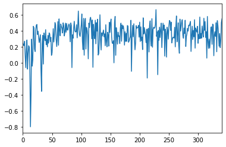

```python
pd.Series(model_score_restrict).plot()
plt.plot(max(model_score_restrict), 'r--')
plt.show()
```

```python
print ("AdaBoost")
print ("--------")
print ("Max Score : ",round(max(model_score_restrict),3))
print ("Average score : ", np.mean(model_score_restrict).round(3))
print ("")
```

```
AdaBoost
--------
Max Score :  0.664
Average score :  0.343
```

In the restricted dataset too, we see a similar modelling performance, with regression tree performing better than other models. However, **AdaBoosting** ensemble technique provides us the best results in this case as well.

Therefore, we will again select *AdaBoost ensemble model* as our preferred model for prediction.

## Question 2.

**(50 points) Download the dataset on spam vs. non-spam emails from the following URL: http://archive.ics.uci.edu/ml/datasets/SpambaseSpecifically, (i) file *“spambase.data”* contains the actual data, and (ii) files *“spambase.names”* and “spambase.DOCUMENTATION” contain the description of the data.This dataset has 4601 records, each record representing a different email message. Each record is described with 58 attributes (indicated in the aforementioned .names file): attributes 1-57 represent various content- based characteristics already extracted from each email message (related to the frequency of certain words or certain punctuation symbols in a message as well as to the usage of capital letters in a message), and the last attribute represents the class label for each message (spam or non-spam).**

**Task: The general task for this assignment is to build two different models for detecting spam messages (based on the email characteristics that are given): (i) the best possible model that you can build in terms of the overall predictive accuracy (i.e., not taking any cost information into account), and (ii) the best cost-sensitive classification model that you can build in terms of the average misclassification cost.** </b>

#### Solution 2

a. Cost insensitive approach  
b. Cost sensitive (10:1) approach

#### a. Cost insensitive Approach

> The write-up is attached following the models at the end.

```python
#Load data
```

```python
spam_names = pd.read_table('spambase/spambase.names')
```

```python
col_names = []
for each in spam_names.values[-57:]:
    col_names.append((each[0].split(':')[0]))
col_names.append('spamOrNot')
```

```python
spam = pd.read_csv('spambase/spambase.data', header = None, names = col_names)
```

```python
spam.head(10)
```

|  | word_freq_make | word_freq_address | word_freq_all | word_freq_3d | word_freq_our | word_freq_over | word_freq_remove | word_freq_internet | word_freq_order | word_freq_mail | ... | char_freq_; | char_freq_( | char_freq_[ | char_freq_! | char_freq_$ | char_freq_# | capital_run_length_average | capital_run_length_longest | capital_run_length_total | spamOrNot |
| --- | --- | --- | --- | --- | --- | --- | --- | --- | --- | --- | --- | --- | --- | --- | --- | --- | --- | --- | --- | --- | --- |
| 0 | 0.00 | 0.64 | 0.64 | 0.0 | 0.32 | 0.00 | 0.00 | 0.00 | 0.00 | 0.00 | ... | 0.00 | 0.000 | 0.0 | 0.778 | 0.000 | 0.000 | 3.756 | 61 | 278 | 1 |
| 1 | 0.21 | 0.28 | 0.50 | 0.0 | 0.14 | 0.28 | 0.21 | 0.07 | 0.00 | 0.94 | ... | 0.00 | 0.132 | 0.0 | 0.372 | 0.180 | 0.048 | 5.114 | 101 | 1028 | 1 |
| 2 | 0.06 | 0.00 | 0.71 | 0.0 | 1.23 | 0.19 | 0.19 | 0.12 | 0.64 | 0.25 | ... | 0.01 | 0.143 | 0.0 | 0.276 | 0.184 | 0.010 | 9.821 | 485 | 2259 | 1 |
| 3 | 0.00 | 0.00 | 0.00 | 0.0 | 0.63 | 0.00 | 0.31 | 0.63 | 0.31 | 0.63 | ... | 0.00 | 0.137 | 0.0 | 0.137 | 0.000 | 0.000 | 3.537 | 40 | 191 | 1 |
| 4 | 0.00 | 0.00 | 0.00 | 0.0 | 0.63 | 0.00 | 0.31 | 0.63 | 0.31 | 0.63 | ... | 0.00 | 0.135 | 0.0 | 0.135 | 0.000 | 0.000 | 3.537 | 40 | 191 | 1 |
| 5 | 0.00 | 0.00 | 0.00 | 0.0 | 1.85 | 0.00 | 0.00 | 1.85 | 0.00 | 0.00 | ... | 0.00 | 0.223 | 0.0 | 0.000 | 0.000 | 0.000 | 3.000 | 15 | 54 | 1 |
| 6 | 0.00 | 0.00 | 0.00 | 0.0 | 1.92 | 0.00 | 0.00 | 0.00 | 0.00 | 0.64 | ... | 0.00 | 0.054 | 0.0 | 0.164 | 0.054 | 0.000 | 1.671 | 4 | 112 | 1 |
| 7 | 0.00 | 0.00 | 0.00 | 0.0 | 1.88 | 0.00 | 0.00 | 1.88 | 0.00 | 0.00 | ... | 0.00 | 0.206 | 0.0 | 0.000 | 0.000 | 0.000 | 2.450 | 11 | 49 | 1 |
| 8 | 0.15 | 0.00 | 0.46 | 0.0 | 0.61 | 0.00 | 0.30 | 0.00 | 0.92 | 0.76 | ... | 0.00 | 0.271 | 0.0 | 0.181 | 0.203 | 0.022 | 9.744 | 445 | 1257 | 1 |
| 9 | 0.06 | 0.12 | 0.77 | 0.0 | 0.19 | 0.32 | 0.38 | 0.00 | 0.06 | 0.00 | ... | 0.04 | 0.030 | 0.0 | 0.244 | 0.081 | 0.000 | 1.729 | 43 | 749 | 1 |

10 rows × 58 columns

```python
np.transpose(spam.describe())
```

|  | count | mean | std | min | 25% | 50% | 75% | max |
| --- | --- | --- | --- | --- | --- | --- | --- | --- |
| word_freq_make | 4601.0 | 0.104553 | 0.305358 | 0.0 | 0.000 | 0.000 | 0.000 | 4.540 |
| word_freq_address | 4601.0 | 0.213015 | 1.290575 | 0.0 | 0.000 | 0.000 | 0.000 | 14.280 |
| word_freq_all | 4601.0 | 0.280656 | 0.504143 | 0.0 | 0.000 | 0.000 | 0.420 | 5.100 |
| word_freq_3d | 4601.0 | 0.065425 | 1.395151 | 0.0 | 0.000 | 0.000 | 0.000 | 42.810 |
| word_freq_our | 4601.0 | 0.312223 | 0.672513 | 0.0 | 0.000 | 0.000 | 0.380 | 10.000 |
| word_freq_over | 4601.0 | 0.095901 | 0.273824 | 0.0 | 0.000 | 0.000 | 0.000 | 5.880 |
| word_freq_remove | 4601.0 | 0.114208 | 0.391441 | 0.0 | 0.000 | 0.000 | 0.000 | 7.270 |
| word_freq_internet | 4601.0 | 0.105295 | 0.401071 | 0.0 | 0.000 | 0.000 | 0.000 | 11.110 |
| word_freq_order | 4601.0 | 0.090067 | 0.278616 | 0.0 | 0.000 | 0.000 | 0.000 | 5.260 |
| word_freq_mail | 4601.0 | 0.239413 | 0.644755 | 0.0 | 0.000 | 0.000 | 0.160 | 18.180 |
| word_freq_receive | 4601.0 | 0.059824 | 0.201545 | 0.0 | 0.000 | 0.000 | 0.000 | 2.610 |
| word_freq_will | 4601.0 | 0.541702 | 0.861698 | 0.0 | 0.000 | 0.100 | 0.800 | 9.670 |
| word_freq_people | 4601.0 | 0.093930 | 0.301036 | 0.0 | 0.000 | 0.000 | 0.000 | 5.550 |
| word_freq_report | 4601.0 | 0.058626 | 0.335184 | 0.0 | 0.000 | 0.000 | 0.000 | 10.000 |
| word_freq_addresses | 4601.0 | 0.049205 | 0.258843 | 0.0 | 0.000 | 0.000 | 0.000 | 4.410 |
| word_freq_free | 4601.0 | 0.248848 | 0.825792 | 0.0 | 0.000 | 0.000 | 0.100 | 20.000 |
| word_freq_business | 4601.0 | 0.142586 | 0.444055 | 0.0 | 0.000 | 0.000 | 0.000 | 7.140 |
| word_freq_email | 4601.0 | 0.184745 | 0.531122 | 0.0 | 0.000 | 0.000 | 0.000 | 9.090 |
| word_freq_you | 4601.0 | 1.662100 | 1.775481 | 0.0 | 0.000 | 1.310 | 2.640 | 18.750 |
| word_freq_credit | 4601.0 | 0.085577 | 0.509767 | 0.0 | 0.000 | 0.000 | 0.000 | 18.180 |
| word_freq_your | 4601.0 | 0.809761 | 1.200810 | 0.0 | 0.000 | 0.220 | 1.270 | 11.110 |
| word_freq_font | 4601.0 | 0.121202 | 1.025756 | 0.0 | 0.000 | 0.000 | 0.000 | 17.100 |
| word_freq_000 | 4601.0 | 0.101645 | 0.350286 | 0.0 | 0.000 | 0.000 | 0.000 | 5.450 |
| word_freq_money | 4601.0 | 0.094269 | 0.442636 | 0.0 | 0.000 | 0.000 | 0.000 | 12.500 |
| word_freq_hp | 4601.0 | 0.549504 | 1.671349 | 0.0 | 0.000 | 0.000 | 0.000 | 20.830 |
| word_freq_hpl | 4601.0 | 0.265384 | 0.886955 | 0.0 | 0.000 | 0.000 | 0.000 | 16.660 |
| word_freq_george | 4601.0 | 0.767305 | 3.367292 | 0.0 | 0.000 | 0.000 | 0.000 | 33.330 |
| word_freq_650 | 4601.0 | 0.124845 | 0.538576 | 0.0 | 0.000 | 0.000 | 0.000 | 9.090 |
| word_freq_lab | 4601.0 | 0.098915 | 0.593327 | 0.0 | 0.000 | 0.000 | 0.000 | 14.280 |
| word_freq_labs | 4601.0 | 0.102852 | 0.456682 | 0.0 | 0.000 | 0.000 | 0.000 | 5.880 |
| word_freq_telnet | 4601.0 | 0.064753 | 0.403393 | 0.0 | 0.000 | 0.000 | 0.000 | 12.500 |
| word_freq_857 | 4601.0 | 0.047048 | 0.328559 | 0.0 | 0.000 | 0.000 | 0.000 | 4.760 |
| word_freq_data | 4601.0 | 0.097229 | 0.555907 | 0.0 | 0.000 | 0.000 | 0.000 | 18.180 |
| word_freq_415 | 4601.0 | 0.047835 | 0.329445 | 0.0 | 0.000 | 0.000 | 0.000 | 4.760 |
| word_freq_85 | 4601.0 | 0.105412 | 0.532260 | 0.0 | 0.000 | 0.000 | 0.000 | 20.000 |
| word_freq_technology | 4601.0 | 0.097477 | 0.402623 | 0.0 | 0.000 | 0.000 | 0.000 | 7.690 |
| word_freq_1999 | 4601.0 | 0.136953 | 0.423451 | 0.0 | 0.000 | 0.000 | 0.000 | 6.890 |
| word_freq_parts | 4601.0 | 0.013201 | 0.220651 | 0.0 | 0.000 | 0.000 | 0.000 | 8.330 |
| word_freq_pm | 4601.0 | 0.078629 | 0.434672 | 0.0 | 0.000 | 0.000 | 0.000 | 11.110 |
| word_freq_direct | 4601.0 | 0.064834 | 0.349916 | 0.0 | 0.000 | 0.000 | 0.000 | 4.760 |
| word_freq_cs | 4601.0 | 0.043667 | 0.361205 | 0.0 | 0.000 | 0.000 | 0.000 | 7.140 |
| word_freq_meeting | 4601.0 | 0.132339 | 0.766819 | 0.0 | 0.000 | 0.000 | 0.000 | 14.280 |
| word_freq_original | 4601.0 | 0.046099 | 0.223812 | 0.0 | 0.000 | 0.000 | 0.000 | 3.570 |
| word_freq_project | 4601.0 | 0.079196 | 0.621976 | 0.0 | 0.000 | 0.000 | 0.000 | 20.000 |
| word_freq_re | 4601.0 | 0.301224 | 1.011687 | 0.0 | 0.000 | 0.000 | 0.110 | 21.420 |
| word_freq_edu | 4601.0 | 0.179824 | 0.911119 | 0.0 | 0.000 | 0.000 | 0.000 | 22.050 |
| word_freq_table | 4601.0 | 0.005444 | 0.076274 | 0.0 | 0.000 | 0.000 | 0.000 | 2.170 |
| word_freq_conference | 4601.0 | 0.031869 | 0.285735 | 0.0 | 0.000 | 0.000 | 0.000 | 10.000 |
| char_freq_; | 4601.0 | 0.038575 | 0.243471 | 0.0 | 0.000 | 0.000 | 0.000 | 4.385 |
| char_freq_( | 4601.0 | 0.139030 | 0.270355 | 0.0 | 0.000 | 0.065 | 0.188 | 9.752 |
| char_freq_[ | 4601.0 | 0.016976 | 0.109394 | 0.0 | 0.000 | 0.000 | 0.000 | 4.081 |
| char_freq_! | 4601.0 | 0.269071 | 0.815672 | 0.0 | 0.000 | 0.000 | 0.315 | 32.478 |
| char_freq_$ | 4601.0 | 0.075811 | 0.245882 | 0.0 | 0.000 | 0.000 | 0.052 | 6.003 |
| char_freq_# | 4601.0 | 0.044238 | 0.429342 | 0.0 | 0.000 | 0.000 | 0.000 | 19.829 |
| capital_run_length_average | 4601.0 | 5.191515 | 31.729449 | 1.0 | 1.588 | 2.276 | 3.706 | 1102.500 |
| capital_run_length_longest | 4601.0 | 52.172789 | 194.891310 | 1.0 | 6.000 | 15.000 | 43.000 | 9989.000 |
| capital_run_length_total | 4601.0 | 283.289285 | 606.347851 | 1.0 | 35.000 | 95.000 | 266.000 | 15841.000 |
| spamOrNot | 4601.0 | 0.394045 | 0.488698 | 0.0 | 0.000 | 0.000 | 1.000 | 1.000 |

```python
## Transforming data to normalize between 0 and 1

spam_norm = (spam - spam.min())/(spam.max() - spam.min())
np.transpose(spam_norm.describe())
```

|  | count | mean | std | min | 25% | 50% | 75% | max |
| --- | --- | --- | --- | --- | --- | --- | --- | --- |
| word_freq_make | 4601.0 | 0.023029 | 0.067259 | 0.0 | 0.000000 | 0.000000 | 0.000000 | 1.0 |
| word_freq_address | 4601.0 | 0.014917 | 0.090376 | 0.0 | 0.000000 | 0.000000 | 0.000000 | 1.0 |
| word_freq_all | 4601.0 | 0.055031 | 0.098852 | 0.0 | 0.000000 | 0.000000 | 0.082353 | 1.0 |
| word_freq_3d | 4601.0 | 0.001528 | 0.032589 | 0.0 | 0.000000 | 0.000000 | 0.000000 | 1.0 |
| word_freq_our | 4601.0 | 0.031222 | 0.067251 | 0.0 | 0.000000 | 0.000000 | 0.038000 | 1.0 |
| word_freq_over | 4601.0 | 0.016310 | 0.046569 | 0.0 | 0.000000 | 0.000000 | 0.000000 | 1.0 |
| word_freq_remove | 4601.0 | 0.015709 | 0.053843 | 0.0 | 0.000000 | 0.000000 | 0.000000 | 1.0 |
| word_freq_internet | 4601.0 | 0.009477 | 0.036100 | 0.0 | 0.000000 | 0.000000 | 0.000000 | 1.0 |
| word_freq_order | 4601.0 | 0.017123 | 0.052969 | 0.0 | 0.000000 | 0.000000 | 0.000000 | 1.0 |
| word_freq_mail | 4601.0 | 0.013169 | 0.035465 | 0.0 | 0.000000 | 0.000000 | 0.008801 | 1.0 |
| word_freq_receive | 4601.0 | 0.022921 | 0.077220 | 0.0 | 0.000000 | 0.000000 | 0.000000 | 1.0 |
| word_freq_will | 4601.0 | 0.056019 | 0.089110 | 0.0 | 0.000000 | 0.010341 | 0.082730 | 1.0 |
| word_freq_people | 4601.0 | 0.016924 | 0.054241 | 0.0 | 0.000000 | 0.000000 | 0.000000 | 1.0 |
| word_freq_report | 4601.0 | 0.005863 | 0.033518 | 0.0 | 0.000000 | 0.000000 | 0.000000 | 1.0 |
| word_freq_addresses | 4601.0 | 0.011157 | 0.058695 | 0.0 | 0.000000 | 0.000000 | 0.000000 | 1.0 |
| word_freq_free | 4601.0 | 0.012442 | 0.041290 | 0.0 | 0.000000 | 0.000000 | 0.005000 | 1.0 |
| word_freq_business | 4601.0 | 0.019970 | 0.062193 | 0.0 | 0.000000 | 0.000000 | 0.000000 | 1.0 |
| word_freq_email | 4601.0 | 0.020324 | 0.058429 | 0.0 | 0.000000 | 0.000000 | 0.000000 | 1.0 |
| word_freq_you | 4601.0 | 0.088645 | 0.094692 | 0.0 | 0.000000 | 0.069867 | 0.140800 | 1.0 |
| word_freq_credit | 4601.0 | 0.004707 | 0.028040 | 0.0 | 0.000000 | 0.000000 | 0.000000 | 1.0 |
| word_freq_your | 4601.0 | 0.072886 | 0.108084 | 0.0 | 0.000000 | 0.019802 | 0.114311 | 1.0 |
| word_freq_font | 4601.0 | 0.007088 | 0.059986 | 0.0 | 0.000000 | 0.000000 | 0.000000 | 1.0 |
| word_freq_000 | 4601.0 | 0.018651 | 0.064273 | 0.0 | 0.000000 | 0.000000 | 0.000000 | 1.0 |
| word_freq_money | 4601.0 | 0.007541 | 0.035411 | 0.0 | 0.000000 | 0.000000 | 0.000000 | 1.0 |
| word_freq_hp | 4601.0 | 0.026380 | 0.080238 | 0.0 | 0.000000 | 0.000000 | 0.000000 | 1.0 |
| word_freq_hpl | 4601.0 | 0.015929 | 0.053239 | 0.0 | 0.000000 | 0.000000 | 0.000000 | 1.0 |
| word_freq_george | 4601.0 | 0.023021 | 0.101029 | 0.0 | 0.000000 | 0.000000 | 0.000000 | 1.0 |
| word_freq_650 | 4601.0 | 0.013734 | 0.059249 | 0.0 | 0.000000 | 0.000000 | 0.000000 | 1.0 |
| word_freq_lab | 4601.0 | 0.006927 | 0.041549 | 0.0 | 0.000000 | 0.000000 | 0.000000 | 1.0 |
| word_freq_labs | 4601.0 | 0.017492 | 0.077667 | 0.0 | 0.000000 | 0.000000 | 0.000000 | 1.0 |
| word_freq_telnet | 4601.0 | 0.005180 | 0.032271 | 0.0 | 0.000000 | 0.000000 | 0.000000 | 1.0 |
| word_freq_857 | 4601.0 | 0.009884 | 0.069025 | 0.0 | 0.000000 | 0.000000 | 0.000000 | 1.0 |
| word_freq_data | 4601.0 | 0.005348 | 0.030578 | 0.0 | 0.000000 | 0.000000 | 0.000000 | 1.0 |
| word_freq_415 | 4601.0 | 0.010049 | 0.069211 | 0.0 | 0.000000 | 0.000000 | 0.000000 | 1.0 |
| word_freq_85 | 4601.0 | 0.005271 | 0.026613 | 0.0 | 0.000000 | 0.000000 | 0.000000 | 1.0 |
| word_freq_technology | 4601.0 | 0.012676 | 0.052357 | 0.0 | 0.000000 | 0.000000 | 0.000000 | 1.0 |
| word_freq_1999 | 4601.0 | 0.019877 | 0.061459 | 0.0 | 0.000000 | 0.000000 | 0.000000 | 1.0 |
| word_freq_parts | 4601.0 | 0.001585 | 0.026489 | 0.0 | 0.000000 | 0.000000 | 0.000000 | 1.0 |
| word_freq_pm | 4601.0 | 0.007077 | 0.039124 | 0.0 | 0.000000 | 0.000000 | 0.000000 | 1.0 |
| word_freq_direct | 4601.0 | 0.013621 | 0.073512 | 0.0 | 0.000000 | 0.000000 | 0.000000 | 1.0 |
| word_freq_cs | 4601.0 | 0.006116 | 0.050589 | 0.0 | 0.000000 | 0.000000 | 0.000000 | 1.0 |
| word_freq_meeting | 4601.0 | 0.009267 | 0.053699 | 0.0 | 0.000000 | 0.000000 | 0.000000 | 1.0 |
| word_freq_original | 4601.0 | 0.012913 | 0.062692 | 0.0 | 0.000000 | 0.000000 | 0.000000 | 1.0 |
| word_freq_project | 4601.0 | 0.003960 | 0.031099 | 0.0 | 0.000000 | 0.000000 | 0.000000 | 1.0 |
| word_freq_re | 4601.0 | 0.014063 | 0.047231 | 0.0 | 0.000000 | 0.000000 | 0.005135 | 1.0 |
| word_freq_edu | 4601.0 | 0.008155 | 0.041321 | 0.0 | 0.000000 | 0.000000 | 0.000000 | 1.0 |
| word_freq_table | 4601.0 | 0.002509 | 0.035149 | 0.0 | 0.000000 | 0.000000 | 0.000000 | 1.0 |
| word_freq_conference | 4601.0 | 0.003187 | 0.028573 | 0.0 | 0.000000 | 0.000000 | 0.000000 | 1.0 |
| char_freq_; | 4601.0 | 0.008797 | 0.055524 | 0.0 | 0.000000 | 0.000000 | 0.000000 | 1.0 |
| char_freq_( | 4601.0 | 0.014257 | 0.027723 | 0.0 | 0.000000 | 0.006665 | 0.019278 | 1.0 |
| char_freq_[ | 4601.0 | 0.004160 | 0.026806 | 0.0 | 0.000000 | 0.000000 | 0.000000 | 1.0 |
| char_freq_! | 4601.0 | 0.008285 | 0.025115 | 0.0 | 0.000000 | 0.000000 | 0.009699 | 1.0 |
| char_freq_$ | 4601.0 | 0.012629 | 0.040960 | 0.0 | 0.000000 | 0.000000 | 0.008662 | 1.0 |
| char_freq_# | 4601.0 | 0.002231 | 0.021652 | 0.0 | 0.000000 | 0.000000 | 0.000000 | 1.0 |
| capital_run_length_average | 4601.0 | 0.003805 | 0.028806 | 0.0 | 0.000534 | 0.001158 | 0.002457 | 1.0 |
| capital_run_length_longest | 4601.0 | 0.005123 | 0.019513 | 0.0 | 0.000501 | 0.001402 | 0.004205 | 1.0 |
| capital_run_length_total | 4601.0 | 0.017821 | 0.038280 | 0.0 | 0.002146 | 0.005934 | 0.016730 | 1.0 |
| spamOrNot | 4601.0 | 0.394045 | 0.488698 | 0.0 | 0.000000 | 0.000000 | 1.000000 | 1.0 |

**Importing libraries:**

```python
from sklearn.neighbors import KNeighborsClassifier as KNC, KNeighborsRegressor as KNR
from sklearn.metrics import confusion_matrix, auc, mean_squared_error, classification_report, roc_curve
from sklearn.model_selection import StratifiedKFold, cross_val_score, train_test_split, cross_val_predict, GridSearchCV
from matplotlib import pyplot as plt
from sklearn.linear_model import LogisticRegression as logit
from pandas.plotting import scatter_matrix
from sklearn.svm import SVC
from sklearn.tree import DecisionTreeClassifier as DTC
from sklearn.naive_bayes import GaussianNB as gnb
import scikitplot as sckplt
```

Getting the Data:

```python
X = spam.iloc[:,:-1]
y = spam.iloc[:,-1]

X_train, X_test, y_train, y_test = train_test_split(X, y, test_size = 0.3)
```

**Selecting classifiers :**

1. Decision Tree
2. Logistic Regression
3. SVM
4. KNN
5. Ensemble Model (Random Forest, XGBoost)
6. Neural Networks

#### 1. Decision Tree

```python
## Nested CV on the data

p_grid = dict(max_depth = list(range(3,20)), min_samples_leaf =[5,10,20],criterion = ['gini', 'entropy'])

inner_cv = KFold(n_splits=6, shuffle=True, random_state=123)
outer_cv = KFold(n_splits=4, shuffle=True, random_state=321)
dtc = DTC()
# Non_nested parameter search and scoring
dt_clf = GridSearchCV(estimator=dtc, param_grid=p_grid, cv=inner_cv)
dt_clf.fit(X_train, y_train)
print ("Best Score : ", dt_clf.best_score_)
print ("Best Estimator :", dt_clf.best_estimator_)
print ("Classification Report : \n",(classification_report(y_test,dt_clf.predict(X_test))) )

# Nested CV with parameter optimization
nested_score = cross_val_score(dt_clf.best_estimator_, X=X, y=y, cv=outer_cv)
print("Mean score after nesting : ", nested_score.mean())
```

```
Best Score :  0.9180124223602485
Best Estimator : DecisionTreeClassifier(class_weight=None, criterion='entropy', max_depth=19,
                       max_features=None, max_leaf_nodes=None,
                       min_impurity_decrease=0.0, min_impurity_split=None,
                       min_samples_leaf=10, min_samples_split=2,
                       min_weight_fraction_leaf=0.0, presort=False,
                       random_state=None, splitter='best')
Classification Report :
               precision    recall  f1-score   support

           0       0.93      0.93      0.93       835
           1       0.89      0.90      0.90       546

    accuracy                           0.92      1381
   macro avg       0.91      0.91      0.91      1381
weighted avg       0.92      0.92      0.92      1381

Mean score after nesting :  0.9176296604087184
```

```
AUC:  0.9611743545875282
```

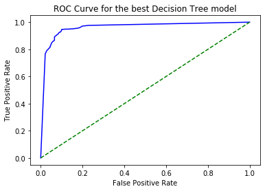

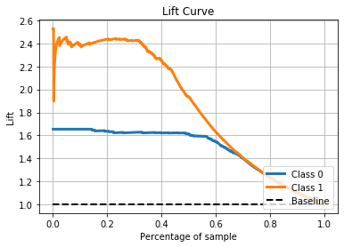

```python
# Plotted ROC curve and Lift Curves
dt_clf1 = dt_clf.best_estimator_
pred_scores = dt_clf1.fit(X_train,y_train).predict_proba(X_test)

fpr, tpr, thresh = roc_curve(y_test, pred_scores[:,1])

auc_score = auc(fpr, tpr)

plt.plot(fpr, tpr, 'blue')
plt.plot([0,1], [0,1], 'g--')
print ("AUC: ", auc_score)
#print ("FPR : ", fpr, " :: TPR : ", tpr)
plt.xlabel("False Positive Rate")
plt.ylabel("True Positive Rate")
plt.title("ROC Curve for the best Decision Tree model")
plt.show()
sckplt.metrics.plot_lift_curve(y_test, pred_scores)
plt.show()
```

```python
cm_dt = confusion_matrix(y_test,dt_clf1.predict(X_test))

print ('Confusion Matrix \n', cm_dt)
```

```
Confusion Matrix
 [[774  61]
 [ 54 492]]
```

```python
cost_mat  = [[0,1],[1,0]]
```

```python
print (" Misclassification Cost : \n",  \
       (cm_dt*cost_mat).sum())
```

```
 Misclassification Cost :
 115
```

#### 2. Logisic Regression

```python
## Nested CV on the data

p_grid = dict(C = list(range(1,24,3)), solver = ['newton-cg', 'liblinear'])

inner_cv = KFold(n_splits=6, shuffle=True, random_state=123)
outer_cv = KFold(n_splits=4, shuffle=True, random_state=321)
log = logit()

# Non_nested parameter search and scoring
log_clf = GridSearchCV(estimator=log, param_grid=p_grid, cv=inner_cv)
log_clf.fit(X_train, y_train)
print ("Best Score : ", log_clf.best_score_)
print ("Best Estimator :", log_clf.best_estimator_)
print ("Classification Report : \n",(classification_report(y_test,log_clf.predict(X_test))) )

# Nested CV with parameter optimization
nested_score = cross_val_score(log_clf.best_estimator_, X=X, y=y, cv=outer_cv)
print("Mean score after nesting : ", nested_score.mean())
```

```
Best Score :  0.9245341614906832
Best Estimator : LogisticRegression(C=10, class_weight=None, dual=False, fit_intercept=True,
                   intercept_scaling=1, l1_ratio=None, max_iter=100,
                   multi_class='warn', n_jobs=None, penalty='l2',
                   random_state=None, solver='newton-cg', tol=0.0001, verbose=0,
                   warm_start=False)
Classification Report :
               precision    recall  f1-score   support

           0       0.94      0.94      0.94       835
           1       0.92      0.91      0.91       546

    accuracy                           0.93      1381
   macro avg       0.93      0.93      0.93      1381
weighted avg       0.93      0.93      0.93      1381

Mean score after nesting :  0.9284929928606505
```

```
AUC:  0.9729135136320765
```

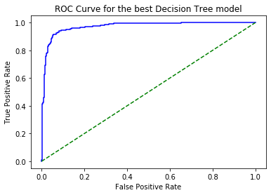

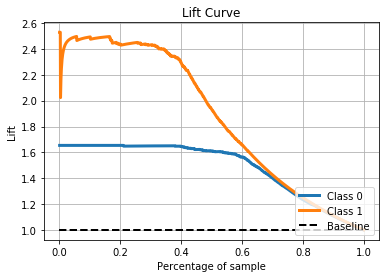

```python
# Plotted ROC curve and Lift Curves
log_clf1 = log_clf.best_estimator_
pred_scores = log_clf1.fit(X_train,y_train).predict_proba(X_test)

fpr, tpr, thresh = roc_curve(y_test, pred_scores[:,1])

auc_score = auc(fpr, tpr)

plt.plot(fpr, tpr, 'blue')
plt.plot([0,1], [0,1], 'g--')
print ("AUC: ", auc_score)
#print ("FPR : ", fpr, " :: TPR : ", tpr)
plt.xlabel("False Positive Rate")
plt.ylabel("True Positive Rate")
plt.title("ROC Curve for the best Decision Tree model")
plt.show()
sckplt.metrics.plot_lift_curve(y_test, pred_scores)
plt.show()
```

```python
cm_log = confusion_matrix(y_test,log_clf1.predict(X_test))

print ('Confusion Matrix \n', cm_log)
```

```
Confusion Matrix
 [[789  46]
 [ 47 499]]
```

```python
cost_mat  = [[0,1],[1,0]]
```

```python
print (" Misclassification Cost : \n",  \
       (cm_log*cost_mat).sum())
```

```
 Misclassification Cost :
 93
```

#### 3. SVM

```python
## Nested CV on the data

p_grid = dict (C=list(range(1,14,4)), kernel = ['rbf'], gamma = list(range(1,14,4)), probability = [True])

inner_cv = KFold(n_splits=5, shuffle=True, random_state=123)
outer_cv = KFold(n_splits=4, shuffle=True, random_state=321)
svm = SVC()

# Non_nested parameter search and scoring
svm_clf = GridSearchCV(estimator=svm, param_grid=p_grid, cv=inner_cv)
svm_clf.fit(X_train, y_train)
print ("Best Score : ", svm_clf.best_score_)
print ("Best Estimator :", svm_clf.best_estimator_)
print ("Classification Report : \n",(classification_report(y_test,svm_clf.predict(X_test))) )

# Nested CV with parameter optimization
nested_score = cross_val_score(svm_clf.best_estimator_, X=X, y=y, cv=outer_cv)
print("Mean score after nesting : ", nested_score.mean())
```

```
Best Score :  0.7068322981366459
Best Estimator : SVC(C=5, cache_size=200, class_weight=None, coef0=0.0,
    decision_function_shape='ovr', degree=3, gamma=1, kernel='rbf', max_iter=-1,
    probability=True, random_state=None, shrinking=True, tol=0.001,
    verbose=False)
Classification Report :
               precision    recall  f1-score   support

           0       0.68      1.00      0.81       835
           1       0.98      0.29      0.44       546

    accuracy                           0.72      1381
   macro avg       0.83      0.64      0.63      1381
weighted avg       0.80      0.72      0.67      1381

Mean score after nesting :  0.7220137498583462
```

```
AUC:  0.8685233927748899
```

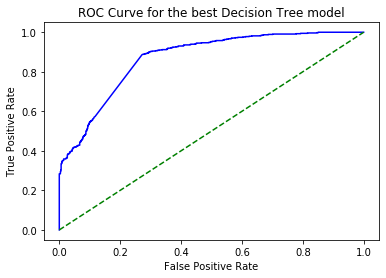

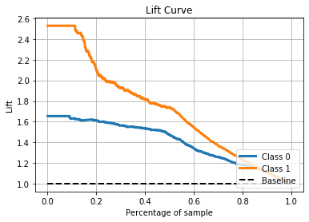

```python
# Plotted ROC curve and Lift Curves
svm_clf1 = svm_clf.best_estimator_
pred_scores = svm_clf1.fit(X_train,y_train).predict_proba(X_test)

fpr, tpr, thresh = roc_curve(y_test, pred_scores[:,1])

auc_score = auc(fpr, tpr)

plt.plot(fpr, tpr, 'blue')
plt.plot([0,1], [0,1], 'g--')
print ("AUC: ", auc_score)
#print ("FPR : ", fpr, " :: TPR : ", tpr)
plt.xlabel("False Positive Rate")
plt.ylabel("True Positive Rate")
plt.title("ROC Curve for the best Decision Tree model")
plt.show()
sckplt.metrics.plot_lift_curve(y_test, pred_scores)
plt.show()
```

```python
cm_svm = confusion_matrix(y_test,svm_clf1.predict(X_test))

print ('Confusion Matrix \n', cm_svm)
```

```
Confusion Matrix
 [[832   3]
 [389 157]]
```

```python
cost_mat  = [[0,1],[1,0]]
```

```python
print (" Misclassification Cost : \n",  \
       (cm_svm*cost_mat).sum())
```

```
 Misclassification Cost :
 392
```

#### 4. KNN

```python
## Nested CV on the data

p_grid = dict (n_neighbors=list(range(3,20)),
               weights = ["distance", "uniform"],
               algorithm = ["ball_tree", "kd_tree"])
inner_cv = KFold(n_splits=6, shuffle=True, random_state=123)
outer_cv = KFold(n_splits=4, shuffle=True, random_state=321)
knnc = KNC()

# Non_nested parameter search and scoring
knc_clf = GridSearchCV(estimator=knnc, param_grid=p_grid, cv=inner_cv)
knc_clf.fit(X_train, y_train)
print ("Best Score : ", knc_clf.best_score_)
print ("Best Estimator :", knc_clf.best_estimator_)
print ("Classification Report : \n",(classification_report(y_test,log_clf.predict(X_test))) )

# Nested CV with parameter optimization
nested_score = cross_val_score(knc_clf.best_estimator_, X=X, y=y, cv=outer_cv)
print("Mean score after nesting : ", nested_score.mean())
```

```
Best Score :  0.8118012422360248
Best Estimator : KNeighborsClassifier(algorithm='ball_tree', leaf_size=30, metric='minkowski',
                     metric_params=None, n_jobs=None, n_neighbors=6, p=2,
                     weights='distance')
Classification Report :
               precision    recall  f1-score   support

           0       0.94      0.94      0.94       835
           1       0.92      0.91      0.91       546

    accuracy                           0.93      1381
   macro avg       0.93      0.93      0.93      1381
weighted avg       0.93      0.93      0.93      1381

Mean score after nesting :  0.8206922147093265
```

```
AUC:  0.8960737864929482
```

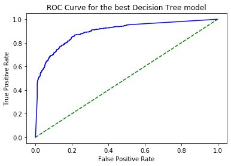

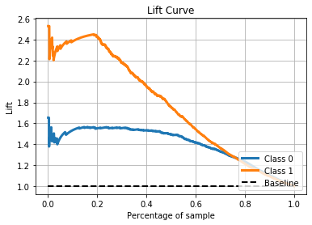

```python
# Plotted ROC curve and Lift Curves
knc_clf1 = knc_clf.best_estimator_
pred_scores = knc_clf1.fit(X_train,y_train).predict_proba(X_test)

fpr, tpr, thresh = roc_curve(y_test, pred_scores[:,1])

auc_score = auc(fpr, tpr)

plt.plot(fpr, tpr, 'blue')
plt.plot([0,1], [0,1], 'g--')
print ("AUC: ", auc_score)
#print ("FPR : ", fpr, " :: TPR : ", tpr)
plt.xlabel("False Positive Rate")
plt.ylabel("True Positive Rate")
plt.title("ROC Curve for the best Decision Tree model")
plt.show()
sckplt.metrics.plot_lift_curve(y_test, pred_scores)
plt.show()
```

```python
cm_knn = confusion_matrix(y_test,knc_clf1.predict(X_test))

print ('Confusion Matrix \n', cm_knn)
```

```
Confusion Matrix
 [[721 114]
 [125 421]]
```

```python
cost_mat  = [[0,1],[1,0]]
```

```python
print (" Misclassification Cost : \n",  \
       (cm_knn*cost_mat).sum())
```

```
 Misclassification Cost :
 239
```

#### 5. Ensemble Methods

##### Random Forest

```python
from sklearn.ensemble import RandomForestClassifier as rfc
```

```python
rfc = rfc(n_estimators = 1000).fit(X_train, y_train)
print(classification_report(y_test,rfc.predict(X_test)))
```

```
              precision    recall  f1-score   support

           0       0.97      0.97      0.97       835
           1       0.95      0.95      0.95       546

    accuracy                           0.96      1381
   macro avg       0.96      0.96      0.96      1381
weighted avg       0.96      0.96      0.96      1381
```

```
AUC:  0.9888563532276107
```

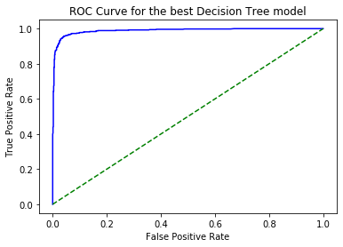

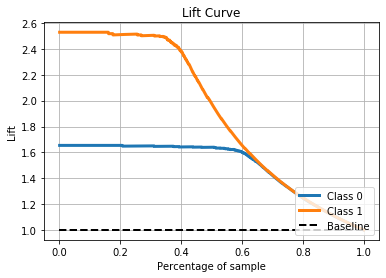

```python
# Plotted ROC curve and Lift Curves
pred_scores = rfc(n_estimators = 1000).fit(X_train,y_train).predict_proba(X_test)


fpr, tpr, thresh = roc_curve(y_test, pred_scores[:,1])

auc_score = auc(fpr, tpr)

plt.plot(fpr, tpr, 'blue')
plt.plot([0,1], [0,1], 'g--')
print ("AUC: ", auc_score)
#print ("FPR : ", fpr, " :: TPR : ", tpr)
plt.xlabel("False Positive Rate")
plt.ylabel("True Positive Rate")
plt.title("ROC Curve for the best Decision Tree model")
plt.show()
sckplt.metrics.plot_lift_curve(y_test, pred_scores)
plt.show()
```

```python
cm_rfc = confusion_matrix(y_test,rfc(n_estimators = 1000).fit(X_train,y_train).predict(X_test))

print ('Confusion Matrix \n', cm_rfc)
```

```
Confusion Matrix
 [[808  27]
 [ 29 517]]
```

```python
cost_mat  = [[0,1],[1,0]]
```

```python
print (" Misclassification Cost : \n",  \
       (cm_rfc*cost_mat).sum())
```

```
 Misclassification Cost :
 56
```

#### 6. Neural Network

```python
from keras.models import Sequential
from keras.layers import Dense
from keras.wrappers.scikit_learn import KerasClassifier
from sklearn.model_selection import KFold
from sklearn.preprocessing import StandardScaler
from sklearn.pipeline import Pipeline
```

```python
classifier = Sequential()

#First Hidden Layer
classifier.add(Dense(40, activation='relu', kernel_initializer='random_normal', input_dim=57))

#Second  Hidden Layer
classifier.add(Dense(28, activation='relu', kernel_initializer='random_normal'))

#Third  Hidden Layer
classifier.add(Dense(18, activation='relu', kernel_initializer='random_normal'))

#Output Layer
classifier.add(Dense(1, activation='sigmoid', kernel_initializer='random_normal'))

#Compiling the neural network
classifier.compile(optimizer ='adam',loss='binary_crossentropy', metrics =['accuracy'])

#Fitting the data to the training dataset
classifier.fit(X_train,y_train, batch_size=200, epochs=20)
```

```
<keras.callbacks.callbacks.History at 0x1a727e1da0>
```

```python
eval_model=classifier.evaluate(X_train, y_train)
print ('Training accuracy : ', eval_model[1])
```

```
Training accuracy :  0.9270186424255371
```

```python
y_pred=classifier.predict(X_test)
y_pred =(y_pred>0.5)
```

```python
cm_nn = confusion_matrix(y_test, y_pred)
print(cm)
```

[output not shown]

```python
cost_mat  = [[0,1],[1,0]]
```

```python
print (" Misclassification Cost : \n",  \
       (cm_nn*cost_mat).sum())
```

```
 Misclassification Cost :
 104
```

```python
print(classification_report(y_test, y_pred))
```

```
              precision    recall  f1-score   support

           0       0.92      0.95      0.94       835
           1       0.93      0.88      0.90       546

    accuracy                           0.92      1381
   macro avg       0.93      0.92      0.92      1381
weighted avg       0.92      0.92      0.92      1381
```

```
AUC:  0.972606435480687
```

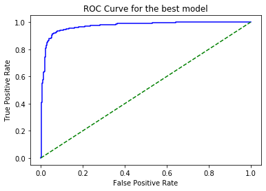

```python
# Plotted ROC curve and Lift Curves

y_pred=classifier.predict(X_test)
fpr, tpr, thresh = roc_curve(y_test, y_pred)

auc_score = auc(fpr, tpr)

plt.plot(fpr, tpr, 'blue')
plt.plot([0,1], [0,1], 'g--')
print ("AUC: ", auc_score)
#print ("FPR : ", fpr, " :: TPR : ", tpr)
plt.xlabel("False Positive Rate")
plt.ylabel("True Positive Rate")
plt.title("ROC Curve for the best model")
plt.show()
#sckplt.metrics.plot_lift_curve(y_test, y_pred)
plt.show()
```

As can be seen from the scores received, **Random forest** model performs the best in terms of both accuracy and average misclassification cost.

### b. Cost Sensitive Approach

For the cost sensitive approach, our trigger is that the average misclassification cost should be minimized by given higher priority to the **False Positives** and we attach at 10x cost for every misclassification done to predict a *Non Spam* email as a *Spam*. We therefore focus on scoring the models by Precision and determine the best models from it.

#### 1. Decision Tree Classifier

```python
## Nested CV on the data

p_grid = dict(max_depth = list(range(3,20)), min_samples_leaf =[5,10,20],criterion = ['gini', 'entropy'])

inner_cv = KFold(n_splits=6, shuffle=True, random_state=123)
outer_cv = KFold(n_splits=4, shuffle=True, random_state=321)
dtc = DTC()
# Non_nested parameter search and scoring
dt_clf = GridSearchCV(estimator=dtc, param_grid=p_grid, cv=inner_cv, scoring = 'precision')
dt_clf.fit(X_train, y_train)
print ("Best Score : ", dt_clf.best_score_)
print ("Best Estimator :", dt_clf.best_estimator_)
print ("Classification Report : \n",(classification_report(y_test,dt_clf.predict(X_test))) )

# Nested CV with parameter optimization
nested_score = cross_val_score(dt_clf.best_estimator_, X=X, y=y, cv=outer_cv)
print("Mean score after nesting : ", nested_score.mean())
```

```
Best Score :  0.9299596269871547
Best Estimator : DecisionTreeClassifier(class_weight=None, criterion='entropy', max_depth=8,
                       max_features=None, max_leaf_nodes=None,
                       min_impurity_decrease=0.0, min_impurity_split=None,
                       min_samples_leaf=5, min_samples_split=2,
                       min_weight_fraction_leaf=0.0, presort=False,
                       random_state=None, splitter='best')
Classification Report :
               precision    recall  f1-score   support

           0       0.91      0.94      0.93       835
           1       0.90      0.86      0.88       546

    accuracy                           0.91      1381
   macro avg       0.91      0.90      0.90      1381
weighted avg       0.91      0.91      0.91      1381

Mean score after nesting :  0.9121939334416198
```

```
AUC:  0.9604165295782063
```

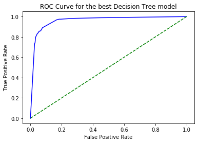

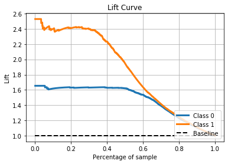

```python
# Plotted ROC curve and Lift Curves
dt_clf2 = dt_clf.best_estimator_
pred_scores = dt_clf2.fit(X_train,y_train).predict_proba(X_test)

fpr, tpr, thresh = roc_curve(y_test, pred_scores[:,1])

auc_score = auc(fpr, tpr)

plt.plot(fpr, tpr, 'blue')
plt.plot([0,1], [0,1], 'g--')
print ("AUC: ", auc_score)
#print ("FPR : ", fpr, " :: TPR : ", tpr)
plt.xlabel("False Positive Rate")
plt.ylabel("True Positive Rate")
plt.title("ROC Curve for the best Decision Tree model")
plt.show()
sckplt.metrics.plot_lift_curve(y_test, pred_scores)
plt.show()
```

```python
cm_dtc2 = confusion_matrix(y_test, dt_clf2.predict(X_test))

print ('Confusion Matrix \n', cm_dtc2)
```

```
Confusion Matrix
 [[784  51]
 [ 77 469]]
```

```python
cost_mat_2 = [[0,10],[1,0]]
```

```python
print (" Misclassification Cost : \n",  \
       (cm_dtc2*cost_mat_2).sum())
```

```
 Misclassification Cost :
 587
```

#### 2. Logisic Regression

```python
## Nested CV on the data

p_grid = dict(C = list(range(1,24,3)), solver = ['newton-cg', 'liblinear'])

inner_cv = KFold(n_splits=6, shuffle=True, random_state=123)
outer_cv = KFold(n_splits=4, shuffle=True, random_state=321)
log = logit()

# Non_nested parameter search and scoring
log_clf = GridSearchCV(estimator=log, param_grid=p_grid, cv=inner_cv, scoring = 'precision' )
log_clf.fit(X_train, y_train)
print ("Best Score : ", log_clf.best_score_)
print ("Best Estimator :", log_clf.best_estimator_)
print ("Classification Report : \n",(classification_report(y_test,log_clf.predict(X_test))) )

# Nested CV with parameter optimization
nested_score = cross_val_score(log_clf.best_estimator_, X=X, y=y, cv=outer_cv)
print("Mean score after nesting : ", nested_score.mean())
```

```
Best Score :  0.9161689917250675
Best Estimator : LogisticRegression(C=10, class_weight=None, dual=False, fit_intercept=True,
                   intercept_scaling=1, l1_ratio=None, max_iter=100,
                   multi_class='warn', n_jobs=None, penalty='l2',
                   random_state=None, solver='newton-cg', tol=0.0001, verbose=0,
                   warm_start=False)
Classification Report :
               precision    recall  f1-score   support

           0       0.94      0.94      0.94       835
           1       0.92      0.91      0.91       546

    accuracy                           0.93      1381
   macro avg       0.93      0.93      0.93      1381
weighted avg       0.93      0.93      0.93      1381

Mean score after nesting :  0.9284929928606505
```

```
AUC:  0.9729135136320765
```

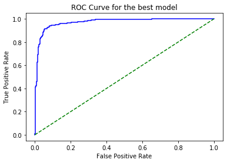

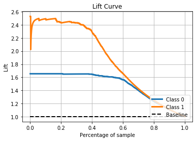

```python
# Plotted ROC curve and Lift Curves
log_clf2 = log_clf.best_estimator_
pred_scores = log_clf2.fit(X_train,y_train).predict_proba(X_test)

fpr, tpr, thresh = roc_curve(y_test, pred_scores[:,1])

auc_score = auc(fpr, tpr)

plt.plot(fpr, tpr, 'blue')
plt.plot([0,1], [0,1], 'g--')
print ("AUC: ", auc_score)
#print ("FPR : ", fpr, " :: TPR : ", tpr)
plt.xlabel("False Positive Rate")
plt.ylabel("True Positive Rate")
plt.title("ROC Curve for the best model")
plt.show()
sckplt.metrics.plot_lift_curve(y_test, pred_scores)
plt.show()
```

```python
cm_log2 = confusion_matrix(y_test, log_clf2.predict(X_test))

print ('Confusion Matrix \n', cm_log2)
```

```
Confusion Matrix
 [[789  46]
 [ 47 499]]
```

```python
cost_mat_2 = [[0,10],[1,0]]
```

```python
print (" Misclassification Cost : \n",  \
       (cm_log2*cost_mat_2).sum())
```

```
 Misclassification Cost :
 507
```